# COMP 352 – Final Project: Footballer Market Evaluation

**Goal:** To predict the market value of a professional footballer next year

**Authors:** Zevin Attisha, Christian Vaikona, Santiago Guerrero, Santiago Pedetti

**Dataset source:** https://www.kaggle.com/datasets/davidcariboo/player-scores

- Environment Setup
1. Data Importing and Pre-processing
2. Data Analysis and Visualization
3. Data Analytics (Modeling)

## Environment Setup

First we must setup our environment to make sure we have all appropriate modules installed. To do this, I have provided 2 methods:

**METHOD 1**

Install all modules using a `.yaml` file via `conda`.

To do this, run:

```
conda env create -f env_setup/environment.yml
```

Then activate the environment by:

```
conda activate data_env
```

**METHOD 2**

You can also use the `requirements.txt` file to download the modules via `pip`.

To do this, first make create and activate your environment:

```
conda create -n my_data_env
conda activate my_data_env
```

You may need to install setup tools. To do this run (Note you may need to change `pip3` to `pip`):

```
pip3 install --upgrade pip setuptools wheel
```

and then run:

```
pip3 install -r env_setup/requirements.txt
```

## 1. Data Importing and Pre-Processing

- Import dataset and describe characteristics such as dimensions, data types, file types, and import methods used
- Clean, wrangle, and handle missing data, duplicate data, etc.
- Encode any categorical variables
- Perform feature engineering on the dataset
- Transform data appropriately using techniques such as aggregation, normalization, and feature construction
- Reduce redundant data and perform need based discretization

We utilize four datasets:

- `player_valuations.csv`: multiple valuation records per player over time
- `players.csv`: one record per player with demographic and categorical info
- `appearances.csv`: one record per player with statistics per game appareance
- `game_lineups.csv`: one record per player with status per game

```python
# Importing libraries
import pandas as pd
import numpy as np
import seaborn as sns
import matplotlib.pyplot as plt
from sklearn.model_selection import train_test_split, TimeSeriesSplit, cross_val_score
from sklearn.metrics import mean_absolute_error, mean_squared_error, r2_score
from sklearn.linear_model import LinearRegression, ElasticNet
from sklearn.ensemble import RandomForestRegressor
from sklearn.neighbors import KNeighborsRegressor
from sklearn.pipeline import Pipeline
from sklearn.impute import SimpleImputer
from sklearn.preprocessing import StandardScaler

# Functions from other scripts trying to reduce repitition
from helper_scripts import (
    evaluate_model,
    cv_mae,
    remove_duplicates
)

# Dataframe formatting
pd.set_option("display.max_columns", None)
np.set_printoptions(suppress=True)
```

```python
# Creating variables for csv paths
PATH_PLAYER_VALUATIONS = "data/raw/player_valuations.csv"
PATH_PLAYERS = "data/raw/players.csv"
PATH_APPEARANCES = "data/raw/appearances.csv"
PATH_LINEUPS = "data/raw/game_lineups.csv"

# Creating Pandas dataframes
player_valuations_df = pd.read_csv(PATH_PLAYER_VALUATIONS)
players_df = pd.read_csv(PATH_PLAYERS)
appearances_df = pd.read_csv(PATH_APPEARANCES)
lineups_df = pd.read_csv(PATH_LINEUPS)

# Displaying dataframe shapes
print("-"*60)
print("Dataframe Shapes")
print("-"*60)

print("player_valuations_df shape:", player_valuations_df.shape)
print("players_df shape:", players_df.shape)
print("appearances_df shape:", appearances_df.shape)
print("lineups_df shape:", lineups_df.shape)
print("\n")

# Displaying dataframe heads
print("-"*60)
print("Dataframe Heads")
print("-"*60)

print("player_valuations_df:")
display(player_valuations_df.head())

print("\nplayers_df:")
display(players_df.head())

print("\nappearances_df:")
display(appearances_df.head())

print("\nlineups_df:")
display(lineups_df.head())
```

```
------------------------------------------------------------
Dataframe Shapes
------------------------------------------------------------
player_valuations_df shape: (496606, 5)
players_df shape: (32601, 23)
appearances_df shape: (1706806, 13)
lineups_df shape: (2191911, 10)


------------------------------------------------------------
Dataframe Heads
------------------------------------------------------------
player_valuations_df:
```

|  | player_id | date | market_value_in_eur | current_club_id | player_club_domestic_competition_id |
| --- | --- | --- | --- | --- | --- |
| 0 | 405973 | 2000-01-20 | 150000 | 3057 | BE1 |
| 1 | 342216 | 2001-07-20 | 100000 | 1241 | SC1 |
| 2 | 3132 | 2003-12-09 | 400000 | 126 | TR1 |
| 3 | 6893 | 2003-12-15 | 900000 | 984 | GB1 |
| 4 | 10 | 2004-10-04 | 7000000 | 398 | IT1 |

```
players_df:
```

|  | player_id | first_name | last_name | name | last_season | current_club_id | player_code | country_of_birth | city_of_birth | country_of_citizenship | date_of_birth | sub_position | position | foot | height_in_cm | contract_expiration_date | agent_name | image_url | url | current_club_domestic_competition_id | current_club_name | market_value_in_eur | highest_market_value_in_eur |
| --- | --- | --- | --- | --- | --- | --- | --- | --- | --- | --- | --- | --- | --- | --- | --- | --- | --- | --- | --- | --- | --- | --- | --- |
| 0 | 10 | Miroslav | Klose | Miroslav Klose | 2015 | 398 | miroslav-klose | Poland | Opole | Germany | 1978-06-09 00:00:00 | Centre-Forward | Attack | right | 184.0 | NaN | ASBW Sport Marketing | https://img.a.transfermarkt.technology/portrai... | https://www.transfermarkt.co.uk/miroslav-klose... | IT1 | Società Sportiva Lazio S.p.A. | 1000000.0 | 30000000.0 |
| 1 | 26 | Roman | Weidenfeller | Roman Weidenfeller | 2017 | 16 | roman-weidenfeller | Germany | Diez | Germany | 1980-08-06 00:00:00 | Goalkeeper | Goalkeeper | left | 190.0 | NaN | Neubauer 13 GmbH | https://img.a.transfermarkt.technology/portrai... | https://www.transfermarkt.co.uk/roman-weidenfe... | L1 | Borussia Dortmund | 750000.0 | 8000000.0 |
| 2 | 65 | Dimitar | Berbatov | Dimitar Berbatov | 2015 | 1091 | dimitar-berbatov | Bulgaria | Blagoevgrad | Bulgaria | 1981-01-30 00:00:00 | Centre-Forward | Attack | NaN | NaN | NaN | CSKA-AS-23 Ltd. | https://img.a.transfermarkt.technology/portrai... | https://www.transfermarkt.co.uk/dimitar-berbat... | GR1 | Panthessalonikios Athlitikos Omilos Konstantin... | 1000000.0 | 34500000.0 |
| 3 | 77 | NaN | Lúcio | Lúcio | 2012 | 506 | lucio | Brazil | Brasília | Brazil | 1978-05-08 00:00:00 | Centre-Back | Defender | NaN | NaN | NaN | NaN | https://img.a.transfermarkt.technology/portrai... | https://www.transfermarkt.co.uk/lucio/profil/s... | IT1 | Juventus Football Club | 200000.0 | 24500000.0 |
| 4 | 80 | Tom | Starke | Tom Starke | 2017 | 27 | tom-starke | East Germany (GDR) | Freital | Germany | 1981-03-18 00:00:00 | Goalkeeper | Goalkeeper | right | 194.0 | NaN | IFM | https://img.a.transfermarkt.technology/portrai... | https://www.transfermarkt.co.uk/tom-starke/pro... | L1 | FC Bayern München | 100000.0 | 3000000.0 |

```
appearances_df:
```

|  | appearance_id | game_id | player_id | player_club_id | player_current_club_id | date | player_name | competition_id | yellow_cards | red_cards | goals | assists | minutes_played |
| --- | --- | --- | --- | --- | --- | --- | --- | --- | --- | --- | --- | --- | --- |
| 0 | 2231978_38004 | 2231978 | 38004 | 853 | 235 | 2012-07-03 | Aurélien Joachim | CLQ | 0 | 0 | 2 | 0 | 90 |
| 1 | 2233748_79232 | 2233748 | 79232 | 8841 | 2698 | 2012-07-05 | Ruslan Abyshov | ELQ | 0 | 0 | 0 | 0 | 90 |
| 2 | 2234413_42792 | 2234413 | 42792 | 6251 | 465 | 2012-07-05 | Sander Puri | ELQ | 0 | 0 | 0 | 0 | 45 |
| 3 | 2234418_73333 | 2234418 | 73333 | 1274 | 6646 | 2012-07-05 | Vegar Hedenstad | ELQ | 0 | 0 | 0 | 0 | 90 |
| 4 | 2234421_122011 | 2234421 | 122011 | 195 | 3008 | 2012-07-05 | Markus Henriksen | ELQ | 0 | 0 | 0 | 1 | 90 |

```
lineups_df:
```

|  | game_lineups_id | date | game_id | player_id | club_id | player_name | type | position | number | team_captain |
| --- | --- | --- | --- | --- | --- | --- | --- | --- | --- | --- |
| 0 | b2dbe01c3656b06c8e23e9de714e26bb | 2013-07-27 | 2317258 | 1443 | 610 | Christian Poulsen | substitutes | Defensive Midfield | 5 | 0 |
| 1 | b50a3ec6d52fd1490aab42042ac4f738 | 2013-07-27 | 2317258 | 5017 | 610 | Niklas Moisander | starting_lineup | Centre-Back | 4 | 0 |
| 2 | 7d890e6d0ff8af84b065839966a0ec81 | 2013-07-27 | 2317258 | 9602 | 1090 | Maarten Martens | substitutes | Left Winger | 11 | 0 |
| 3 | 8c355268678b9bbc7084221b1f0fde36 | 2013-07-27 | 2317258 | 12282 | 610 | Daley Blind | starting_lineup | Left-Back | 17 | 0 |
| 4 | 76193074d549e5fdce4cdcbba0d66247 | 2013-07-27 | 2317258 | 25427 | 1090 | Roy Beerens | starting_lineup | Right Winger | 23 | 0 |

```python
# Checking for duplicates

remove_duplicates("Player Valuations Dataset", player_valuations_df)
remove_duplicates("Players Dataset", players_df)
remove_duplicates("Appearances Dataset", appearances_df)
remove_duplicates("Lineups Dataset",lineups_df)
```

```
------------------------------
Player Valuations Dataset
------------------------------
Total rows: 496606
Duplicate rows: 0
No duplicate rows found.

------------------------------
Players Dataset
------------------------------
Total rows: 32601
Duplicate rows: 0
No duplicate rows found.

------------------------------
Appearances Dataset
------------------------------
Total rows: 1706806
Duplicate rows: 0
No duplicate rows found.

------------------------------
Lineups Dataset
------------------------------
Total rows: 2191911
Duplicate rows: 0
No duplicate rows found.
```

```python
# Types per dataset
print("player_valuations_df dtypes:")
display(player_valuations_df.dtypes)

print("\nplayers_df dtypes:")
display(players_df.dtypes)

print("\nappearances_df dtypes:")
display(appearances_df.dtypes)

print("\nlineups_df dtypes:")
display(lineups_df.dtypes)
print("\n")

# Columns that display the most missing values in descending order
print("-"*60)
print("Missing Values in player_valuations_df:")
print("-"*60)
display(player_valuations_df.isna().sum().sort_values(ascending=False).head(len(player_valuations_df)))

print("-"*60)
print("Missing values in players_df:")
print("-"*60)
display(players_df.isna().sum().sort_values(ascending=False).head(len(players_df)))

print("-"*60)
print("Missing values in appearances_df:")
print("-"*60)
display(appearances_df.isna().sum().sort_values(ascending=False).head(len(appearances_df)))

print("-"*60)
print("Missing values in lineups_df:")
print("-"*60)
display(lineups_df.isna().sum().sort_values(ascending=False).head(len(lineups_df)))
```

```
player_valuations_df dtypes:
```

```
player_id                               int64
date                                   object
market_value_in_eur                     int64
current_club_id                         int64
player_club_domestic_competition_id    object
dtype: object
```

```
players_df dtypes:
```

```
player_id                                 int64
first_name                               object
last_name                                object
name                                     object
last_season                               int64
current_club_id                           int64
player_code                              object
country_of_birth                         object
city_of_birth                            object
country_of_citizenship                   object
date_of_birth                            object
sub_position                             object
position                                 object
foot                                     object
height_in_cm                            float64
contract_expiration_date                 object
agent_name                               object
image_url                                object
url                                      object
current_club_domestic_competition_id     object
current_club_name                        object
market_value_in_eur                     float64
highest_market_value_in_eur             float64
dtype: object
```

```
appearances_df dtypes:
```

```
appearance_id             object
game_id                    int64
player_id                  int64
player_club_id             int64
player_current_club_id     int64
date                      object
player_name               object
competition_id            object
yellow_cards               int64
red_cards                  int64
goals                      int64
assists                    int64
minutes_played             int64
dtype: object
```

```
lineups_df dtypes:
```

```
game_lineups_id    object
date               object
game_id             int64
player_id           int64
club_id             int64
player_name        object
type               object
position           object
number             object
team_captain        int64
dtype: object
```

```
------------------------------------------------------------
Missing Values in player_valuations_df:
------------------------------------------------------------
```

```
player_id                              0
date                                   0
market_value_in_eur                    0
current_club_id                        0
player_club_domestic_competition_id    0
dtype: int64
```

```
------------------------------------------------------------
Missing values in players_df:
------------------------------------------------------------
```

```
agent_name                              16019
contract_expiration_date                12091
country_of_birth                         2799
foot                                     2536
city_of_birth                            2455
height_in_cm                             2256
first_name                               2062
highest_market_value_in_eur              1523
market_value_in_eur                      1523
country_of_citizenship                    383
sub_position                              180
date_of_birth                              47
position                                    0
player_code                                 0
current_club_id                             0
last_season                                 0
name                                        0
image_url                                   0
url                                         0
current_club_domestic_competition_id        0
current_club_name                           0
last_name                                   0
player_id                                   0
dtype: int64
```

```
------------------------------------------------------------
Missing values in appearances_df:
------------------------------------------------------------
```

```
player_name               6
appearance_id             0
game_id                   0
player_id                 0
player_club_id            0
player_current_club_id    0
date                      0
competition_id            0
yellow_cards              0
red_cards                 0
goals                     0
assists                   0
minutes_played            0
dtype: int64
```

```
------------------------------------------------------------
Missing values in lineups_df:
------------------------------------------------------------
```

```
position           3
game_lineups_id    0
date               0
game_id            0
player_id          0
club_id            0
player_name        0
type               0
number             0
team_captain       0
dtype: int64
```

```python
# Clean players_df

# Copy to avoid altering original data
p = players_df.copy()

# Sort by player
p = p.sort_values(['player_id']).reset_index(drop=True)

# Drop where target variable isn't available
p = p.dropna(subset=["highest_market_value_in_eur"]) # Also ends up clearing nulls in "market_value_in_eur"

# Parse birth date
p["date_of_birth"] = pd.to_datetime(p["date_of_birth"], errors="coerce")

# Birth date required for age feature
p = p.dropna(subset=["date_of_birth"])

# Having both position and sub_position provides cleaner statistical analysis
p = p.dropna(subset=["sub_position"]) # Removes "Missing" values from position also

# Drop to make right vs left foot correlation feature or impute for general use?
p = p.dropna(subset=["foot"])
# OR
# p["foot"] = p["foot"].fillna("Missing")

# Save original names before encoding
p['sub_position_name'] = p['sub_position'].copy()
p['position_name'] = p['position'].copy()
p['foot_name'] = p['foot'].copy()

# Label encoding for foot
foot_map = {'left': 0, 'right': 1, 'both': 2}
p['foot_encoded'] = p['foot'].map(foot_map)

# One-hot encoding for position
p = pd.get_dummies(p, columns=['position'], prefix='pos', drop_first=False, dtype=int)
position_cols = [col for col in p.columns if col.startswith('pos_')]

# Frequency encoding for sub_position
subpos_freq = p['sub_position'].value_counts(normalize=True)
p['sub_position'] = p['sub_position'].map(subpos_freq)
p = p.rename(columns={'sub_position': 'sub_position_freq'})

# Handle missing categoricals
# p["sub_position"] = p["sub_position"].fillna("Missing")

# # Numeric height + impute (less than 3% of height values were null)
p["height_in_cm"] = pd.to_numeric(p["height_in_cm"], errors="coerce")
p["height_in_cm"] = p["height_in_cm"].fillna(p["height_in_cm"].median())

# Keep only safe player-level features (no bias/leakage)
"""
Dropping The Following:

[Cannot Impute]
agent_name
contract_expiration_date
first_name
country_of_birth
city_of_birth
country_of_citizenship

[Irrelavant/Bias]
market_value_in_eur
current_club_domestic_competition_id
url
image_url
player_code
last_season
name
last_name
highest_market_value_in_eur

[Encoded]
foot - label encoding - simpler 0/1/2 to left/right/both
position - one-hot encoding - only 4 series added
sub_position - frequency encoding - At risk of data leakage if 13 different series created or values encoded

[Potentially Bring Back For Feature]
current_club_name OR current_club_id - frequency of players at a club correlation to value
"""
keep_player_cols = [
    "player_id",
    "height_in_cm",
    "sub_position_name",
    "sub_position_freq",
    "foot_name",
    "foot_encoded",
    "date_of_birth",
    "position_name"
] + position_cols
p = p[keep_player_cols].copy()

print("p shape:", p.shape)
p.head()

# Keep here at bottom to check on df when needed
# print("-"*60)
# print("Missing values in players_df:")
# print("-"*60)
# display(p.isna().sum().sort_values(ascending=False).head(len(p)))
```

```
p shape: (29054, 12)
```

|  | player_id | height_in_cm | sub_position_name | sub_position_freq | foot_name | foot_encoded | date_of_birth | position_name | pos_Attack | pos_Defender | pos_Goalkeeper | pos_Midfield |
| --- | --- | --- | --- | --- | --- | --- | --- | --- | --- | --- | --- | --- |
| 0 | 10 | 184.0 | Centre-Forward | 0.140497 | right | 1 | 1978-06-09 | Attack | 1 | 0 | 0 | 0 |
| 1 | 26 | 190.0 | Goalkeeper | 0.104977 | left | 0 | 1980-08-06 | Goalkeeper | 0 | 0 | 1 | 0 |
| 4 | 80 | 194.0 | Goalkeeper | 0.104977 | right | 1 | 1981-03-18 | Goalkeeper | 0 | 0 | 1 | 0 |
| 7 | 132 | 179.0 | Attacking Midfield | 0.068803 | both | 2 | 1980-10-04 | Midfield | 0 | 0 | 0 | 1 |
| 8 | 162 | 193.0 | Goalkeeper | 0.104977 | right | 1 | 1976-06-13 | Goalkeeper | 0 | 0 | 1 | 0 |

```python
# Clean appearances_df

# Copy to avoid altering original data
app = appearances_df.copy()

# Parse date to datetime
app['date'] = pd.to_datetime(app['date'], errors='coerce')

# Extract year from match date
app['year'] = app['date'].dt.year

# Fill missing performance stats with 0 (player appeared but didn't score/assist)
app['yellow_cards'] = app['yellow_cards'].fillna(0)
app['red_cards'] = app['red_cards'].fillna(0)
app['goals'] = app['goals'].fillna(0)
app['assists'] = app['assists'].fillna(0)
app['minutes_played'] = app['minutes_played'].fillna(0)

# Keep only safe player-level features (no bias/leakage)
"""
Dropping The Following:

player_name - player_id is present
appearance_id
game_id
player_club_id
player_current_club_id
competition_id
"""
keep_player_cols = [
    "player_id",
    "date",
    "yellow_cards",
    "red_cards",
    "goals",
    "assists",
    "minutes_played",
    "year"
]
app = app[keep_player_cols].copy()

print("app shape:", app.shape)
app.head()

# Keep here at bottom to check on df when needed
# print("-"*60)
# print("Missing values in appearances_df:")
# print("-"*60)
# display(app.isna().sum().sort_values(ascending=False).head(len(app)))
```

```
app shape: (1706806, 8)
```

|  | player_id | date | yellow_cards | red_cards | goals | assists | minutes_played | year |
| --- | --- | --- | --- | --- | --- | --- | --- | --- |
| 0 | 38004 | 2012-07-03 | 0 | 0 | 2 | 0 | 90 | 2012 |
| 1 | 79232 | 2012-07-05 | 0 | 0 | 0 | 0 | 90 | 2012 |
| 2 | 42792 | 2012-07-05 | 0 | 0 | 0 | 0 | 45 | 2012 |
| 3 | 73333 | 2012-07-05 | 0 | 0 | 0 | 0 | 90 | 2012 |
| 4 | 122011 | 2012-07-05 | 0 | 0 | 0 | 1 | 90 | 2012 |

```python
# Clean player_valuations_df

# Copy to avoid altering original data
pv = player_valuations_df.copy()

# Parse date
pv["date"] = pd.to_datetime(pv["date"], errors="coerce")

# Sort by player and date
pv = pv.sort_values(['player_id', 'date']).reset_index(drop=True)

"""
Dropping the following:

current_club_id
player_club_domestic_competition_id
"""
keep_player_cols = [
    "player_id",
    "date",
    "market_value_in_eur"
]
pv = pv[keep_player_cols].copy()

print(f"pv shape: {pv.shape}")
print(f"Date range: {pv['date'].min()} to {pv['date'].max()}")
print(f"Unique players: {pv['player_id'].nunique()}")
print("pv head:")
pv.head()

# Keep here at bottom to check on df when needed
# print("-"*60)
# print("Missing values in player_valuations_df:")
# print("-"*60)
# display(pv.isna().sum().sort_values(ascending=False).head(len(pv)))
```

```
pv shape: (496606, 3)
Date range: 2000-01-20 00:00:00 to 2025-04-06 00:00:00
Unique players: 31078
pv head:
```

|  | player_id | date | market_value_in_eur |
| --- | --- | --- | --- |
| 0 | 10 | 2004-10-04 | 7000000 |
| 1 | 10 | 2005-01-07 | 9000000 |
| 2 | 10 | 2005-05-05 | 12000000 |
| 3 | 10 | 2005-09-30 | 15000000 |
| 4 | 10 | 2006-01-09 | 20000000 |

```python
# Clean lineups_df

# Copy to avoid altering original data
lu = lineups_df.copy()

# Parse date
lu["date"] = pd.to_datetime(lu["date"], errors="coerce")

# Sort by player and date
lu = lu.sort_values(['player_id', 'date']).reset_index(drop=True)

# Dropping where position is not available
# lu = lu.dropna(subset=["position"])

# Renaming type column and label encoding values
# Simplified to indicate if starter or not per appearance
lu = lu.rename(columns={"type": "is_starter"})
type_map = {'substitutes': 0, 'starting_lineup': 1}
lu['is_starter'] = lu['is_starter'].map(type_map)

# Dropping where positon is outdated or categorical, not specific
# lu = lu[~lu['position'].isin(['midfield', 'Attack', 'Defender', 'Sweeper'])]

"""
Dropping the following:

game_lineups_id
game_id
club_id
player_name
number
position - present in p (cleaned players_df)
"""
keep_player_cols = [
    "date",
    "player_id",
    "is_starter",
    "team_captain"
]
lu = lu[keep_player_cols].copy()
print("lu shape:", lu.shape)
lu.head()

# Keep here at bottom to check on df when needed
# print("-"*60)
# print("Missing values in lineups_df:")
# print("-"*60)
# display(lu.isna().sum().sort_values(ascending=False).head(len(lu)))
```

```
lu shape: (2191911, 4)
```

|  | date | player_id | is_starter | team_captain |
| --- | --- | --- | --- | --- |
| 0 | 2013-08-18 | 10 | 1 | 0 |
| 1 | 2013-08-25 | 10 | 1 | 0 |
| 2 | 2013-08-31 | 10 | 1 | 0 |
| 3 | 2013-09-15 | 10 | 1 | 0 |
| 4 | 2013-09-19 | 10 | 0 | 0 |

```python
# Lifetime Cumulative Statistics - app

# Sort by player and date
app = app.sort_values(['player_id', 'date']).reset_index(drop=True)

# Creating cumulative features
app['total_goals'] = app.groupby(['player_id'])['goals'].cumsum()
app['total_assists'] = app.groupby(['player_id'])['assists'].cumsum()
app['total_minutes'] = app.groupby(['player_id'])['minutes_played'].cumsum()
app['total_yellow_cards'] = app.groupby(['player_id'])['yellow_cards'].cumsum()
app['total_red_cards'] = app.groupby(['player_id'])['red_cards'].cumsum()
app['total_appearances'] = app.groupby(['player_id']).cumcount() + 1 # +1 because of 0-based count

'''grit feature- FEATURE FOR GOAL to yellow or red card CORRELATION

  '''

# Goal, assist, yellow-card, red-card rate
app['goal_rate'] = round(app['total_goals'] / app['total_appearances'],3)
app['assist_rate'] = round(app['total_assists'] / app['total_appearances'],3)
app['yellow_card_rate'] = round(app['total_yellow_cards'] / app['total_appearances'],3)
app['red_card_rate'] = round(app['total_red_cards'] / app['total_appearances'],3)

# Keep only the most recent row per player per date (in case multiple games same day)
app_cumulative = app.groupby(['player_id', 'date']).tail(1).reset_index(drop=True)

# Select columns for merge
app_for_merge = app_cumulative[[
    'player_id', 'date',
    'total_goals', 'total_assists', 'total_minutes',
    'total_yellow_cards', 'total_red_cards', 'total_appearances',
    'goal_rate', 'assist_rate', 'yellow_card_rate', 'red_card_rate'
]].copy()

# Verify cumulative logic is working correctly
print("\nChecking cumulative growth for a sample player:")
sample_player_id = app_for_merge['player_id'].iloc[100] if len(app_for_merge) > 100 else app_for_merge['player_id'].iloc[0]
sample_data = app_for_merge[app_for_merge['player_id'] == sample_player_id].head(10)
print(f"\nPlayer ID: {sample_player_id}")
display(sample_data[['date', 'total_goals', 'total_assists', 'total_minutes','total_yellow_cards', 'total_red_cards', 'total_appearances',
                     'goal_rate', 'assist_rate', 'yellow_card_rate', 'red_card_rate']])
print("All numerical stats should either remain constant or increase as time goes on")

print(f"\napp_for_merge shape: {app_for_merge.shape}")
print(f"Date range: {app_for_merge['date'].min()} to {app_for_merge['date'].max()}")
print(f"Unique players: {app_for_merge['player_id'].nunique()}")
print("\napp_for_merge head:")
app_for_merge.head()

# Keep here at bottom to check on df when needed
# print("-"*60)
# print("Missing values in app_for_merge:")
# print("-"*60)
# display(app_for_merge.isna().sum().sort_values(ascending=False).head(len(app_for_merge)))
```

```
Checking cumulative growth for a sample player:

Player ID: 10
```

|  | date | total_goals | total_assists | total_minutes | total_yellow_cards | total_red_cards | total_appearances | goal_rate | assist_rate | yellow_card_rate | red_card_rate |
| --- | --- | --- | --- | --- | --- | --- | --- | --- | --- | --- | --- |
| 0 | 2012-08-23 | 1 | 0 | 83 | 1 | 0 | 1 | 1.000 | 0.000 | 1.000 | 0.0 |
| 1 | 2012-08-26 | 1 | 0 | 173 | 2 | 0 | 2 | 0.500 | 0.000 | 1.000 | 0.0 |
| 2 | 2012-09-02 | 3 | 0 | 262 | 3 | 0 | 3 | 1.000 | 0.000 | 1.000 | 0.0 |
| 3 | 2012-09-16 | 4 | 0 | 352 | 3 | 0 | 4 | 1.000 | 0.000 | 0.750 | 0.0 |
| 4 | 2012-09-20 | 4 | 0 | 442 | 3 | 0 | 5 | 0.800 | 0.000 | 0.600 | 0.0 |
| 5 | 2012-09-23 | 4 | 0 | 456 | 3 | 0 | 6 | 0.667 | 0.000 | 0.500 | 0.0 |
| 6 | 2012-09-26 | 4 | 0 | 546 | 3 | 0 | 7 | 0.571 | 0.000 | 0.429 | 0.0 |
| 7 | 2012-09-30 | 4 | 1 | 636 | 4 | 0 | 8 | 0.500 | 0.125 | 0.500 | 0.0 |
| 8 | 2012-10-07 | 6 | 1 | 708 | 4 | 0 | 9 | 0.667 | 0.111 | 0.444 | 0.0 |
| 9 | 2012-10-20 | 7 | 1 | 798 | 4 | 0 | 10 | 0.700 | 0.100 | 0.400 | 0.0 |

```
All numerical stats should either remain constant or increase as time goes on

app_for_merge shape: (1706792, 12)
Date range: 2012-07-03 00:00:00 to 2025-04-10 00:00:00
Unique players: 25689

app_for_merge head:
```

|  | player_id | date | total_goals | total_assists | total_minutes | total_yellow_cards | total_red_cards | total_appearances | goal_rate | assist_rate | yellow_card_rate | red_card_rate |
| --- | --- | --- | --- | --- | --- | --- | --- | --- | --- | --- | --- | --- |
| 0 | 10 | 2012-08-23 | 1 | 0 | 83 | 1 | 0 | 1 | 1.0 | 0.0 | 1.00 | 0.0 |
| 1 | 10 | 2012-08-26 | 1 | 0 | 173 | 2 | 0 | 2 | 0.5 | 0.0 | 1.00 | 0.0 |
| 2 | 10 | 2012-09-02 | 3 | 0 | 262 | 3 | 0 | 3 | 1.0 | 0.0 | 1.00 | 0.0 |
| 3 | 10 | 2012-09-16 | 4 | 0 | 352 | 3 | 0 | 4 | 1.0 | 0.0 | 0.75 | 0.0 |
| 4 | 10 | 2012-09-20 | 4 | 0 | 442 | 3 | 0 | 5 | 0.8 | 0.0 | 0.60 | 0.0 |

```python
# Lifetime Cumulative Statistics - lu

# Sort by player and date
lu = lu.sort_values(['player_id', 'date']).reset_index(drop=True)

# Creating cumulative features
lu['total_starts'] = lu.groupby(['player_id'])['is_starter'].cumsum()
lu['total_captaincies'] = lu.groupby(['player_id'])['team_captain'].cumsum()

# Create a total games count within the lu dataframe itself
lu['total_games_in_lineup'] = lu.groupby(['player_id']).cumcount() + 1

# Live rates for tendency to start or be captain throughout career
lu['captain_rate'] = round(lu['total_captaincies'] / lu['total_games_in_lineup'], 3)
lu['starting_rate'] = round(lu['total_starts'] / lu['total_games_in_lineup'], 3)

# Keep only the most recent row per player per date (in case multiple games same day)
lu_cumulative = lu.groupby(['player_id', 'date']).tail(1).reset_index(drop=True)

# Select columns for merge
lu_for_merge = lu_cumulative[[
    'player_id',
    'date',
    'is_starter',
    'total_starts',
    'team_captain',
    'total_captaincies',
    'starting_rate',
    'captain_rate'
]].copy()

# Verify cumulative logic is working correctly
print("\nChecking cumulative growth for a sample player:")
sample_player_id = lu_for_merge['player_id'].iloc[100] if len(lu_for_merge) > 100 else lu_for_merge['player_id'].iloc[0]
sample_data = lu_for_merge[lu_for_merge['player_id'] == sample_player_id].head(10)
print(f"\nPlayer ID: {sample_player_id}")
display(sample_data[['date', 'total_starts', 'total_captaincies', 'starting_rate', 'captain_rate' ]])
print("All stats should either remain constant or increase as time goes on")

print(f"\nlu_for_merge shape: {lu_for_merge.shape}")
print(f"Date range: {lu_for_merge['date'].min()} to {lu_for_merge['date'].max()}")
print(f"Unique players: {lu_for_merge['player_id'].nunique()}")
print("\nlu_for_merge head:")
lu_for_merge.head()

# Keep here at bottom to check on df when needed
# print("-"*60)
# print("Missing values in lu_for_merge:")
# print("-"*60)
# display(lu_for_merge.isna().sum().sort_values(ascending=False).head(len(lu_for_merge)))
```

```
Checking cumulative growth for a sample player:

Player ID: 10
```

|  | date | total_starts | total_captaincies | starting_rate | captain_rate |
| --- | --- | --- | --- | --- | --- |
| 0 | 2013-08-18 | 1 | 0 | 1.000 | 0.0 |
| 1 | 2013-08-25 | 2 | 0 | 1.000 | 0.0 |
| 2 | 2013-08-31 | 3 | 0 | 1.000 | 0.0 |
| 3 | 2013-09-15 | 4 | 0 | 1.000 | 0.0 |
| 4 | 2013-09-19 | 4 | 0 | 0.800 | 0.0 |
| 5 | 2013-09-22 | 5 | 0 | 0.833 | 0.0 |
| 6 | 2013-10-20 | 5 | 0 | 0.714 | 0.0 |
| 7 | 2013-10-27 | 5 | 0 | 0.625 | 0.0 |
| 8 | 2013-10-30 | 6 | 0 | 0.667 | 0.0 |
| 9 | 2013-11-03 | 7 | 0 | 0.700 | 0.0 |

```
All stats should either remain constant or increase as time goes on

lu_for_merge shape: (2191895, 8)
Date range: 2013-07-02 00:00:00 to 2024-03-17 00:00:00
Unique players: 85235

lu_for_merge head:
```

|  | player_id | date | is_starter | total_starts | team_captain | total_captaincies | starting_rate | captain_rate |
| --- | --- | --- | --- | --- | --- | --- | --- | --- |
| 0 | 10 | 2013-08-18 | 1 | 1 | 0 | 0 | 1.0 | 0.0 |
| 1 | 10 | 2013-08-25 | 1 | 2 | 0 | 0 | 1.0 | 0.0 |
| 2 | 10 | 2013-08-31 | 1 | 3 | 0 | 0 | 1.0 | 0.0 |
| 3 | 10 | 2013-09-15 | 1 | 4 | 0 | 0 | 1.0 | 0.0 |
| 4 | 10 | 2013-09-19 | 0 | 4 | 0 | 0 | 0.8 | 0.0 |

### CHECKPOINT 1

4 Tables have been curated:

- `p` : player_id, height_in_cm, sub_position, foot_encoded, date_of_birth, pos_Attack, pos_Defender, pos_Goalkeeper, pos_Midfield
- `pv` : player_id, date, market_value_in_eur
- `app_for_merge` : player_id, date, total_goals, total_assists, total_minutes, total_yellow_cards, total_red_cards, total_appearances, goal_rate, assist_rate, yellow_card_rate, red_card_rate
- `lu_for_merge` : player_id, date, is_starter, total_starts, team_captain, total_captaincies, starting_rate, captain_rate

```python
print(f"p shape: {p.shape}")
print(f"Unique players: {p['player_id'].nunique()}")
print("p head:")
display(p.head())

print(f"pv shape: {pv.shape}")
print(f"Date range: {pv['date'].min()} to {pv['date'].max()}")
print(f"Unique players: {pv['player_id'].nunique()}")
print("pv head:")
display(pv.head())

print(f"app_for_merge shape: {app_for_merge.shape}")
print(f"Date range: {app_for_merge['date'].min()} to {app_for_merge['date'].max()}")
print(f"Unique players: {app_for_merge['player_id'].nunique()}")
print("app_for_merge head:")
display(app_for_merge.head())

print(f"lu_for_merge shape: {lu_for_merge.shape}")
print(f"Date range: {lu_for_merge['date'].min()} to {lu_for_merge['date'].max()}")
print(f"Unique players: {lu_for_merge['player_id'].nunique()}")
print("lu_for_merge head:")
display(lu_for_merge.head())
```

```
p shape: (29054, 12)
Unique players: 29054
p head:
```

|  | player_id | height_in_cm | sub_position_name | sub_position_freq | foot_name | foot_encoded | date_of_birth | position_name | pos_Attack | pos_Defender | pos_Goalkeeper | pos_Midfield |
| --- | --- | --- | --- | --- | --- | --- | --- | --- | --- | --- | --- | --- |
| 0 | 10 | 184.0 | Centre-Forward | 0.140497 | right | 1 | 1978-06-09 | Attack | 1 | 0 | 0 | 0 |
| 1 | 26 | 190.0 | Goalkeeper | 0.104977 | left | 0 | 1980-08-06 | Goalkeeper | 0 | 0 | 1 | 0 |
| 4 | 80 | 194.0 | Goalkeeper | 0.104977 | right | 1 | 1981-03-18 | Goalkeeper | 0 | 0 | 1 | 0 |
| 7 | 132 | 179.0 | Attacking Midfield | 0.068803 | both | 2 | 1980-10-04 | Midfield | 0 | 0 | 0 | 1 |
| 8 | 162 | 193.0 | Goalkeeper | 0.104977 | right | 1 | 1976-06-13 | Goalkeeper | 0 | 0 | 1 | 0 |

```
pv shape: (496606, 3)
Date range: 2000-01-20 00:00:00 to 2025-04-06 00:00:00
Unique players: 31078
pv head:
```

|  | player_id | date | market_value_in_eur |
| --- | --- | --- | --- |
| 0 | 10 | 2004-10-04 | 7000000 |
| 1 | 10 | 2005-01-07 | 9000000 |
| 2 | 10 | 2005-05-05 | 12000000 |
| 3 | 10 | 2005-09-30 | 15000000 |
| 4 | 10 | 2006-01-09 | 20000000 |

```
app_for_merge shape: (1706792, 12)
Date range: 2012-07-03 00:00:00 to 2025-04-10 00:00:00
Unique players: 25689
app_for_merge head:
```

|  | player_id | date | total_goals | total_assists | total_minutes | total_yellow_cards | total_red_cards | total_appearances | goal_rate | assist_rate | yellow_card_rate | red_card_rate |
| --- | --- | --- | --- | --- | --- | --- | --- | --- | --- | --- | --- | --- |
| 0 | 10 | 2012-08-23 | 1 | 0 | 83 | 1 | 0 | 1 | 1.0 | 0.0 | 1.00 | 0.0 |
| 1 | 10 | 2012-08-26 | 1 | 0 | 173 | 2 | 0 | 2 | 0.5 | 0.0 | 1.00 | 0.0 |
| 2 | 10 | 2012-09-02 | 3 | 0 | 262 | 3 | 0 | 3 | 1.0 | 0.0 | 1.00 | 0.0 |
| 3 | 10 | 2012-09-16 | 4 | 0 | 352 | 3 | 0 | 4 | 1.0 | 0.0 | 0.75 | 0.0 |
| 4 | 10 | 2012-09-20 | 4 | 0 | 442 | 3 | 0 | 5 | 0.8 | 0.0 | 0.60 | 0.0 |

```
lu_for_merge shape: (2191895, 8)
Date range: 2013-07-02 00:00:00 to 2024-03-17 00:00:00
Unique players: 85235
lu_for_merge head:
```

|  | player_id | date | is_starter | total_starts | team_captain | total_captaincies | starting_rate | captain_rate |
| --- | --- | --- | --- | --- | --- | --- | --- | --- |
| 0 | 10 | 2013-08-18 | 1 | 1 | 0 | 0 | 1.0 | 0.0 |
| 1 | 10 | 2013-08-25 | 1 | 2 | 0 | 0 | 1.0 | 0.0 |
| 2 | 10 | 2013-08-31 | 1 | 3 | 0 | 0 | 1.0 | 0.0 |
| 3 | 10 | 2013-09-15 | 1 | 4 | 0 | 0 | 1.0 | 0.0 |
| 4 | 10 | 2013-09-19 | 0 | 4 | 0 | 0 | 0.8 | 0.0 |

```python
# Merging pv and p

# Merge pv (Player Valuations) with p (Player Info)
valuation_profiles = pv.merge(p, on='player_id', how='left')

# Choosing series to drop all rows with null values at all
# Rows only have nulls if there was no player information to join to the valuations
# Dropped records should account for all records of any player_id that was dropped in the process
valuation_profiles = valuation_profiles.dropna(subset=["foot_name"])

# Create age at valuation
valuation_profiles['age_at_valuation'] = round((valuation_profiles['date'] - valuation_profiles['date_of_birth']).dt.days / 365.25,2)

# Ensuring general types
valuation_profiles = valuation_profiles.astype({'player_id': int,
                    'market_value_in_eur': int,
                    'height_in_cm': float,
                    'sub_position_name': str,
                    'sub_position_freq': float,
                    'foot_name': str,
                    'foot_encoded': int,
                    'position_name': str,
                    'pos_Attack': int,
                    'pos_Defender': int,
                    'pos_Goalkeeper': int,
                    'pos_Midfield': int,
                    'age_at_valuation': float
                    })

# Ensuring date types
valuation_profiles['date'] = pd.to_datetime(valuation_profiles['date'])
valuation_profiles['date_of_birth'] = pd.to_datetime(valuation_profiles['date_of_birth'])

# Ensuring data is sorted
valuation_profiles = valuation_profiles.sort_values(['player_id', 'date']).reset_index(drop=True)

print("valuation_profiles shape:", valuation_profiles.shape)
print(f"Date range: {valuation_profiles['date'].min()} to {valuation_profiles['date'].max()}")
valuation_profiles.head()

# Keep here at bottom to check on df when needed
# print("-"*60)
# print("Missing values in valuation_profiles:")
# print("-"*60)
# display(valuation_profiles.isna().sum().sort_values(ascending=False).head(len(valuation_profiles)))
```

```
valuation_profiles shape: (480533, 15)
Date range: 2001-07-20 00:00:00 to 2025-04-06 00:00:00
```

|  | player_id | date | market_value_in_eur | height_in_cm | sub_position_name | sub_position_freq | foot_name | foot_encoded | date_of_birth | position_name | pos_Attack | pos_Defender | pos_Goalkeeper | pos_Midfield | age_at_valuation |
| --- | --- | --- | --- | --- | --- | --- | --- | --- | --- | --- | --- | --- | --- | --- | --- |
| 0 | 10 | 2004-10-04 | 7000000 | 184.0 | Centre-Forward | 0.140497 | right | 1 | 1978-06-09 | Attack | 1 | 0 | 0 | 0 | 26.32 |
| 1 | 10 | 2005-01-07 | 9000000 | 184.0 | Centre-Forward | 0.140497 | right | 1 | 1978-06-09 | Attack | 1 | 0 | 0 | 0 | 26.58 |
| 2 | 10 | 2005-05-05 | 12000000 | 184.0 | Centre-Forward | 0.140497 | right | 1 | 1978-06-09 | Attack | 1 | 0 | 0 | 0 | 26.90 |
| 3 | 10 | 2005-09-30 | 15000000 | 184.0 | Centre-Forward | 0.140497 | right | 1 | 1978-06-09 | Attack | 1 | 0 | 0 | 0 | 27.31 |
| 4 | 10 | 2006-01-09 | 20000000 | 184.0 | Centre-Forward | 0.140497 | right | 1 | 1978-06-09 | Attack | 1 | 0 | 0 | 0 | 27.59 |

```python
# Merging app_for_merge with lu_for_merge

# Merging app_for_merge (Appearance Info) with lu_for_merge (Lineup Info)
game_stats = app_for_merge.merge(lu_for_merge, on=['player_id', 'date'], how='inner')

# Time discrepancy from inital date between both datasets
game_stats.drop(columns=['total_starts', 'total_captaincies', 'starting_rate', 'captain_rate'],
                inplace=True)

# Ensuring general types
game_stats = game_stats.astype({'player_id': int,
                    'total_goals': int,
                    'total_assists': int,
                    'total_minutes': int,
                    'total_yellow_cards': int,
                    'total_red_cards': int,
                    'total_appearances': int,
                    'goal_rate': float,
                    'assist_rate': float,
                    'yellow_card_rate': float,
                    'red_card_rate': float,
                    'is_starter': int,
                    'team_captain': int
                    })

# Ensuring date types
game_stats['date'] = pd.to_datetime(game_stats['date'])

# Ensuring data is sorted
game_stats = game_stats.sort_values(['player_id', 'date']).reset_index(drop=True)

print(f"game_stats shape: {game_stats.shape}")
print(f"Date range: {game_stats['date'].min()} to {game_stats['date'].max()}")
game_stats.head()

# Keep here at bottom to check on df when needed
# print("-"*60)
# print("Missing values in game_stats:")
# print("-"*60)
# display(game_stats.isna().sum().sort_values(ascending=False).head(len(game_stats)))
```

```
game_stats shape: (1342295, 14)
Date range: 2013-07-02 00:00:00 to 2024-03-17 00:00:00
```

|  | player_id | date | total_goals | total_assists | total_minutes | total_yellow_cards | total_red_cards | total_appearances | goal_rate | assist_rate | yellow_card_rate | red_card_rate | is_starter | team_captain |
| --- | --- | --- | --- | --- | --- | --- | --- | --- | --- | --- | --- | --- | --- | --- |
| 0 | 10 | 2013-08-18 | 16 | 3 | 2675 | 8 | 0 | 37 | 0.432 | 0.081 | 0.216 | 0.0 | 1 | 0 |
| 1 | 10 | 2013-08-25 | 16 | 5 | 2758 | 8 | 0 | 38 | 0.421 | 0.132 | 0.211 | 0.0 | 1 | 0 |
| 2 | 10 | 2013-08-31 | 17 | 5 | 2840 | 8 | 0 | 39 | 0.436 | 0.128 | 0.205 | 0.0 | 1 | 0 |
| 3 | 10 | 2013-09-15 | 17 | 5 | 2930 | 8 | 0 | 40 | 0.425 | 0.125 | 0.200 | 0.0 | 1 | 0 |
| 4 | 10 | 2013-09-22 | 17 | 5 | 3020 | 8 | 0 | 41 | 0.415 | 0.122 | 0.195 | 0.0 | 1 | 0 |

### CHECKPOINT 2

We now have two datasets formed by merges:

- `valuation_profiles`: player_id, date, market_value_in_eur, height_in_cm, sub_position_name, sub_position_freq, foot_name, foot_encoded, date_of_birth, position_name, pos_Attack, pos_Defender, pos_Goalkeeper, pos_Midfield, age_at_valuation
- `game_stats`: player_id, date, total_goals, total_assists, total_minutes, total_yellow_cards, total_red_cards, total_appearances, goal_rate, assist_rate, yellow_card_rate, red_card_rate, is_starter, team_captain

```python
"""
DIRECT MERGE_ASOF PRODUCES PERSISTENT ERROR

Reason:
pd.merge_asof requires that ALL dates be in order chronologically,
but the dates in the dataset restart/jump back everytime there is a new player_id
"""
# ---------------------------------------------------------------------------
# ValueError                                Traceback (most recent call last)
# Cell In[132], line 8
#       5 game_stats = game_stats.sort_values(['player_id', 'date']).reset_index(drop=True)
#       7 # Merge: get most recent game stats before each valuation
# ----> 8 total_merge = pd.merge_asof(
#       9     valuation_profiles.sort_values(['player_id', 'date']).reset_index(drop=True),
#      10     game_stats.sort_values(['player_id', 'date']).reset_index(drop=True),
#      11     on='date',
#      12     by='player_id',
#      13     direction='backward'
#      14 )
#      16 # Filter to dates where game data exists
#      17 total_merge = total_merge[total_merge['date'] >= '2012-07-01'].copy()

# File /opt/anaconda3/envs/final_project_data_env/lib/python3.12/site-packages/pandas/core/reshape/merge.py:708, in merge_asof(left, right, on, left_on, right_on, left_index, right_index, by, left_by, right_by, suffixes, tolerance, allow_exact_matches, direction)
#     456 ***
#     457 Perform a merge by key distance.
#     458
#    (...)    689 4 2016-05-25 13:30:00.048   AAPL   98.00       100     NaN     NaN
#     690 ***
#     691 op = _AsOfMerge(
#     692     left,
#     693     right,
#    (...)    706     direction=direction,
# ...
# -> 2183     raise ValueError(f"{side} keys must be sorted")
#    2185 if isinstance(values, ArrowExtensionArray):
#    2186     values = values._maybe_convert_datelike_array()

# ValueError: left keys must be sorted

# Error-producing code:

# # Sort both datasets
# valuation_profiles = valuation_profiles.sort_values(['player_id', 'date']).reset_index(drop=True)
# game_stats = game_stats.sort_values(['player_id', 'date']).reset_index(drop=True)

# # Merge: get most recent game stats before each valuation
# total_merge = pd.merge_asof(
#     valuation_profiles.sort_values(['player_id', 'date']).reset_index(drop=True),
#     game_stats.sort_values(['player_id', 'date']).reset_index(drop=True),
#     on='date',
#     by='player_id',
#     direction='backward'
# )
```

```
' \nDIRECT MERGE_ASOF PRODUCES PERSISTENT ERROR \n\nReason:\npd.merge_asof requires that ALL dates be in order chronologically, \nbut the dates in the dataset restart/jump back everytime there is a new player_id\n'
```

```python
# Merging by splitting by player_id, merging on date, concatinating resulting tables (Slower solution to error)
all_merges = []
for player_id in valuation_profiles['player_id'].unique():
    vp = valuation_profiles[valuation_profiles['player_id'] == player_id].reset_index(drop=True)
    gs = game_stats[game_stats['player_id'] == player_id].drop(columns='player_id').reset_index(drop=True)

    if len(gs) > 0:
        merged = pd.merge_asof(vp, gs, on='date', direction='backward')
        all_merges.append(merged)

total_merge = pd.concat(all_merges, ignore_index=True)
```

```python
print(type(total_merge))
```

```
<class 'pandas.core.frame.DataFrame'>
```

```python
# Choosing random series to remove all nulls
total_merge = total_merge.dropna(subset=["assist_rate"])

# Ensuring data is sorted
total_merge = total_merge.sort_values(['player_id', 'date']).reset_index(drop=True)

# Ensure types
total_merge = total_merge.astype({'player_id': int,
                                  'market_value_in_eur': int,
                                  'height_in_cm': float,
                                  'sub_position_name': str,
                                  'sub_position_freq': float,
                                  'foot_name': str,
                                  'foot_encoded': int,
                                  'position_name': str,
                                  'pos_Attack': int,
                                  'pos_Defender': int,
                                  'pos_Goalkeeper': int,
                                  'pos_Midfield': int,
                                  'age_at_valuation': float,
                                  'total_goals': int,
                                  'total_assists': int,
                                  'total_minutes': int,
                                  'total_yellow_cards': int,
                                  'total_red_cards': int,
                                  'total_appearances': int,
                                  'goal_rate': float,
                                  'assist_rate': float,
                                  'yellow_card_rate': float,
                                  'red_card_rate': float,
                                  'is_starter': int,
                                  'team_captain': int
})
total_merge['date'] = pd.to_datetime(total_merge['date'])
total_merge['date_of_birth'] = pd.to_datetime(total_merge['date_of_birth'])

print(total_merge.shape)
total_merge.head()

# Keep here at bottom to check on df when needed
# print("-"*60)
# print("Missing values in total_merge:")
# print("-"*60)
# display(total_merge.isna().sum().sort_values(ascending=False).head(len(total_merge)))
```

```
(264965, 27)
```

|  | player_id | date | market_value_in_eur | height_in_cm | sub_position_name | sub_position_freq | foot_name | foot_encoded | date_of_birth | position_name | pos_Attack | pos_Defender | pos_Goalkeeper | pos_Midfield | age_at_valuation | total_goals | total_assists | total_minutes | total_yellow_cards | total_red_cards | total_appearances | goal_rate | assist_rate | yellow_card_rate | red_card_rate | is_starter | team_captain |
| --- | --- | --- | --- | --- | --- | --- | --- | --- | --- | --- | --- | --- | --- | --- | --- | --- | --- | --- | --- | --- | --- | --- | --- | --- | --- | --- | --- |
| 0 | 10 | 2014-01-07 | 1000000 | 184.0 | Centre-Forward | 0.140497 | right | 1 | 1978-06-09 | Attack | 1 | 0 | 0 | 0 | 35.58 | 21 | 5 | 3625 | 9 | 0 | 50 | 0.420 | 0.100 | 0.180 | 0.0 | 1 | 0 |
| 1 | 10 | 2014-07-07 | 1000000 | 184.0 | Centre-Forward | 0.140497 | right | 1 | 1978-06-09 | Attack | 1 | 0 | 0 | 0 | 36.08 | 24 | 8 | 4805 | 10 | 0 | 65 | 0.369 | 0.123 | 0.154 | 0.0 | 1 | 0 |
| 2 | 10 | 2015-01-07 | 1000000 | 184.0 | Centre-Forward | 0.140497 | right | 1 | 1978-06-09 | Attack | 1 | 0 | 0 | 0 | 36.58 | 28 | 11 | 5301 | 12 | 0 | 80 | 0.350 | 0.138 | 0.150 | 0.0 | 1 | 0 |
| 3 | 10 | 2015-07-01 | 1000000 | 184.0 | Centre-Forward | 0.140497 | right | 1 | 1978-06-09 | Attack | 1 | 0 | 0 | 0 | 37.06 | 40 | 17 | 7094 | 16 | 0 | 105 | 0.381 | 0.162 | 0.152 | 0.0 | 0 | 0 |
| 4 | 10 | 2016-01-04 | 1000000 | 184.0 | Centre-Forward | 0.140497 | right | 1 | 1978-06-09 | Attack | 1 | 0 | 0 | 0 | 37.57 | 40 | 19 | 7730 | 18 | 0 | 116 | 0.345 | 0.164 | 0.155 | 0.0 | 1 | 0 |

```python
# Create target variable
total_merge['target_value'] = total_merge.groupby('player_id')['market_value_in_eur'].shift(-1)
total_merge['next_valuation_date'] = total_merge.groupby('player_id')['date'].shift(-1)
total_merge['days_until_next'] = (total_merge['next_valuation_date'] - total_merge['date']).dt.days

# Add historical value features
total_merge['value_lag_1'] = total_merge.groupby('player_id')['market_value_in_eur'].shift(1)
total_merge['value_change'] = total_merge['market_value_in_eur'] - total_merge['value_lag_1']
total_merge['value_change_pct'] = (total_merge['market_value_in_eur'] - total_merge['value_lag_1']) / total_merge['value_lag_1'].clip(lower=1)
total_merge['value_lag_1'] = total_merge['value_lag_1'].fillna(total_merge['market_value_in_eur'])
total_merge['value_change'] = total_merge['value_change'].fillna(0)
total_merge['value_change_pct'] = total_merge['value_change_pct'].fillna(0)

# Final cleanup
total_merge = total_merge.dropna(subset=['target_value']).copy()

# Ensuring sorted table
total_merge = total_merge.sort_values(['player_id', 'date']).reset_index(drop=True)

print(f"Final dataset: {total_merge.shape}")
total_merge.head(25)

# Keep here at bottom to check on df when needed
# print("-"*60)
# print("Missing values in total_merge:")
# print("-"*60)
# display(total_merge.isna().sum().sort_values(ascending=False).head(len(total_merge)))
```

```
Final dataset: (243583, 33)
```

|  | player_id | date | market_value_in_eur | height_in_cm | sub_position_name | sub_position_freq | foot_name | foot_encoded | date_of_birth | position_name | pos_Attack | pos_Defender | pos_Goalkeeper | pos_Midfield | age_at_valuation | total_goals | total_assists | total_minutes | total_yellow_cards | total_red_cards | total_appearances | goal_rate | assist_rate | yellow_card_rate | red_card_rate | is_starter | team_captain | target_value | next_valuation_date | … |
| --- | --- | --- | --- | --- | --- | --- | --- | --- | --- | --- | --- | --- | --- | --- | --- | --- | --- | --- | --- | --- | --- | --- | --- | --- | --- | --- | --- | --- | --- | --- |
| 0 | 10 | 2014-01-07 | 1000000 | 184.0 | Centre-Forward | 0.140497 | right | 1 | 1978-06-09 | Attack | 1 | 0 | 0 | 0 | 35.58 | 21 | 5 | 3625 | 9 | 0 | 50 | 0.420 | 0.100 | 0.180 | 0.000 | 1 | 0 | 1000000.0 | 2014-07-07 | … |
| 1 | 10 | 2014-07-07 | 1000000 | 184.0 | Centre-Forward | 0.140497 | right | 1 | 1978-06-09 | Attack | 1 | 0 | 0 | 0 | 36.08 | 24 | 8 | 4805 | 10 | 0 | 65 | 0.369 | 0.123 | 0.154 | 0.000 | 1 | 0 | 1000000.0 | 2015-01-07 | … |
| 2 | 10 | 2015-01-07 | 1000000 | 184.0 | Centre-Forward | 0.140497 | right | 1 | 1978-06-09 | Attack | 1 | 0 | 0 | 0 | 36.58 | 28 | 11 | 5301 | 12 | 0 | 80 | 0.350 | 0.138 | 0.150 | 0.000 | 1 | 0 | 1000000.0 | 2015-07-01 | … |
| 3 | 10 | 2015-07-01 | 1000000 | 184.0 | Centre-Forward | 0.140497 | right | 1 | 1978-06-09 | Attack | 1 | 0 | 0 | 0 | 37.06 | 40 | 17 | 7094 | 16 | 0 | 105 | 0.381 | 0.162 | 0.152 | 0.000 | 0 | 0 | 1000000.0 | 2016-01-04 | … |
| 4 | 26 | 2014-07-10 | 5000000 | 190.0 | Goalkeeper | 0.104977 | left | 0 | 1980-08-06 | Goalkeeper | 0 | 0 | 1 | 0 | 33.92 | 0 | 0 | 8256 | 3 | 2 | 92 | 0.000 | 0.000 | 0.033 | 0.022 | 1 | 1 | 3000000.0 | 2015-02-04 | … |
| 5 | 26 | 2015-02-04 | 3000000 | 190.0 | Goalkeeper | 0.104977 | left | 0 | 1980-08-06 | Goalkeeper | 0 | 0 | 1 | 0 | 34.50 | 0 | 0 | 9966 | 3 | 2 | 111 | 0.000 | 0.000 | 0.027 | 0.018 | 1 | 0 | 2000000.0 | 2015-07-01 | … |
| 6 | 26 | 2015-07-01 | 2000000 | 190.0 | Goalkeeper | 0.104977 | left | 0 | 1980-08-06 | Goalkeeper | 0 | 0 | 1 | 0 | 34.90 | 0 | 0 | 11136 | 3 | 2 | 124 | 0.000 | 0.000 | 0.024 | 0.016 | 1 | 0 | 1000000.0 | 2015-10-16 | … |
| 7 | 26 | 2015-10-16 | 1000000 | 190.0 | Goalkeeper | 0.104977 | left | 0 | 1980-08-06 | Goalkeeper | 0 | 0 | 1 | 0 | 35.19 | 0 | 0 | 11586 | 3 | 2 | 129 | 0.000 | 0.000 | 0.023 | 0.016 | 1 | 0 | 1000000.0 | 2016-02-15 | … |
| 8 | 26 | 2016-02-15 | 1000000 | 190.0 | Goalkeeper | 0.104977 | left | 0 | 1980-08-06 | Goalkeeper | 0 | 0 | 1 | 0 | 35.53 | 0 | 0 | 11946 | 3 | 2 | 133 | 0.000 | 0.000 | 0.023 | 0.015 | 1 | 0 | 1000000.0 | 2016-07-22 | … |
| 9 | 26 | 2016-07-22 | 1000000 | 190.0 | Goalkeeper | 0.104977 | left | 0 | 1980-08-06 | Goalkeeper | 0 | 0 | 1 | 0 | 35.96 | 0 | 0 | 12396 | 4 | 2 | 138 | 0.000 | 0.000 | 0.029 | 0.014 | 1 | 0 | 1000000.0 | 2017-02-07 | … |
| 10 | 26 | 2017-02-07 | 1000000 | 190.0 | Goalkeeper | 0.104977 | left | 0 | 1980-08-06 | Goalkeeper | 0 | 0 | 1 | 0 | 36.51 | 0 | 0 | 13416 | 4 | 2 | 149 | 0.000 | 0.000 | 0.027 | 0.013 | 1 | 0 | 1000000.0 | 2017-06-19 | … |
| 11 | 26 | 2017-06-19 | 1000000 | 190.0 | Goalkeeper | 0.104977 | left | 0 | 1980-08-06 | Goalkeeper | 0 | 0 | 1 | 0 | 36.87 | 0 | 0 | 13416 | 4 | 2 | 149 | 0.000 | 0.000 | 0.027 | 0.013 | 1 | 0 | 750000.0 | 2017-12-28 | … |
| 12 | 80 | 2014-07-10 | 1000000 | 194.0 | Goalkeeper | 0.104977 | right | 1 | 1981-03-18 | Goalkeeper | 0 | 0 | 1 | 0 | 33.31 | 0 | 0 | 630 | 0 | 0 | 7 | 0.000 | 0.000 | 0.000 | 0.000 | 1 | 0 | 500000.0 | 2015-02-04 | … |
| 13 | 80 | 2015-02-04 | 500000 | 194.0 | Goalkeeper | 0.104977 | right | 1 | 1981-03-18 | Goalkeeper | 0 | 0 | 1 | 0 | 33.88 | 0 | 0 | 630 | 0 | 0 | 7 | 0.000 | 0.000 | 0.000 | 0.000 | 1 | 0 | 500000.0 | 2015-07-01 | … |
| 14 | 80 | 2015-07-01 | 500000 | 194.0 | Goalkeeper | 0.104977 | right | 1 | 1981-03-18 | Goalkeeper | 0 | 0 | 1 | 0 | 34.29 | 0 | 0 | 630 | 0 | 0 | 7 | 0.000 | 0.000 | 0.000 | 0.000 | 1 | 0 | 300000.0 | 2016-02-15 | … |
| 15 | 80 | 2016-02-15 | 300000 | 194.0 | Goalkeeper | 0.104977 | right | 1 | 1981-03-18 | Goalkeeper | 0 | 0 | 1 | 0 | 34.91 | 0 | 0 | 630 | 0 | 0 | 7 | 0.000 | 0.000 | 0.000 | 0.000 | 1 | 0 | 200000.0 | 2016-07-22 | … |
| 16 | 80 | 2016-07-22 | 200000 | 194.0 | Goalkeeper | 0.104977 | right | 1 | 1981-03-18 | Goalkeeper | 0 | 0 | 1 | 0 | 35.35 | 0 | 0 | 630 | 0 | 0 | 7 | 0.000 | 0.000 | 0.000 | 0.000 | 1 | 0 | 200000.0 | 2017-02-07 | … |
| 17 | 80 | 2017-02-07 | 200000 | 194.0 | Goalkeeper | 0.104977 | right | 1 | 1981-03-18 | Goalkeeper | 0 | 0 | 1 | 0 | 35.89 | 0 | 0 | 630 | 0 | 0 | 7 | 0.000 | 0.000 | 0.000 | 0.000 | 1 | 0 | 200000.0 | 2017-06-19 | … |
| 18 | 80 | 2017-06-19 | 200000 | 194.0 | Goalkeeper | 0.104977 | right | 1 | 1981-03-18 | Goalkeeper | 0 | 0 | 1 | 0 | 36.25 | 0 | 0 | 900 | 0 | 0 | 10 | 0.000 | 0.000 | 0.000 | 0.000 | 1 | 0 | 100000.0 | 2017-09-21 | … |
| 19 | 80 | 2017-09-21 | 100000 | 194.0 | Goalkeeper | 0.104977 | right | 1 | 1981-03-18 | Goalkeeper | 0 | 0 | 1 | 0 | 36.51 | 0 | 0 | 900 | 0 | 0 | 10 | 0.000 | 0.000 | 0.000 | 0.000 | 1 | 0 | 100000.0 | 2017-12-28 | … |
| 20 | 80 | 2017-12-28 | 100000 | 194.0 | Goalkeeper | 0.104977 | right | 1 | 1981-03-18 | Goalkeeper | 0 | 0 | 1 | 0 | 36.78 | 0 | 0 | 1080 | 0 | 0 | 12 | 0.000 | 0.000 | 0.000 | 0.000 | 1 | 0 | 100000.0 | 2018-06-05 | … |
| 21 | 132 | 2014-01-15 | 2000000 | 179.0 | Attacking Midfield | 0.068803 | both | 2 | 1980-10-04 | Midfield | 0 | 0 | 0 | 1 | 33.28 | 4 | 2 | 2181 | 7 | 0 | 35 | 0.114 | 0.057 | 0.200 | 0.000 | 0 | 0 | 2000000.0 | 2014-08-12 | … |
| 22 | 132 | 2014-08-12 | 2000000 | 179.0 | Attacking Midfield | 0.068803 | both | 2 | 1980-10-04 | Midfield | 0 | 0 | 0 | 1 | 33.85 | 6 | 2 | 3156 | 12 | 0 | 54 | 0.111 | 0.037 | 0.222 | 0.000 | 0 | 0 | 2000000.0 | 2015-02-12 | … |
| 23 | 132 | 2015-02-12 | 2000000 | 179.0 | Attacking Midfield | 0.068803 | both | 2 | 1980-10-04 | Midfield | 0 | 0 | 0 | 1 | 34.36 | 8 | 4 | 3805 | 13 | 0 | 69 | 0.116 | 0.058 | 0.188 | 0.000 | 1 | 0 | 1500000.0 | 2015-07-01 | … |
| 24 | 132 | 2015-07-01 | 1500000 | 179.0 | Attacking Midfield | 0.068803 | both | 2 | 1980-10-04 | Midfield | 0 | 0 | 0 | 1 | 34.74 | 9 | 4 | 3968 | 13 | 0 | 76 | 0.118 | 0.053 | 0.171 | 0.000 | 0 | 0 | 1500000.0 | 2016-02-09 | … |

```python
# Feature Discretization

# Age groups
total_merge['age_group'] = pd.cut(
    total_merge['age_at_valuation'],
    bins=[0, 23, 28, 33, 50],
    labels=['Young (≤23)', 'Prime (24-28)', 'Experienced (29-33)', 'Veteran (34+)']
)

# Current value tiers
total_merge['value_tier'] = pd.cut(
    total_merge['market_value_in_eur'],
    bins=[0, 1e6, 5e6, 20e6, float('inf')],
    labels=['Low (<1M)', 'Medium (1-5M)', 'High (5-20M)', 'Elite (>20M)'],
    right=False
)

# Target value tiers
total_merge['target_value_tier'] = pd.cut(
    total_merge['target_value'],
    bins=[0, 1e6, 5e6, 20e6, float('inf')],
    labels=['Low (<1M)', 'Medium (1-5M)', 'High (5-20M)', 'Elite (>20M)'],
    right=False
)

print("\nDiscretization Summary:")
print(f"Age Group Distribution:\n{total_merge['age_group'].value_counts().sort_index()}\n")
print(f"Current Value Tier Distribution:\n{total_merge['value_tier'].value_counts().sort_index()}\n")
print(f"Target Value Tier Distribution:\n{total_merge['target_value_tier'].value_counts().sort_index()}\n")
```

```
Discretization Summary:
Age Group Distribution:
age_group
Young (≤23)            55308
Prime (24-28)          95389
Experienced (29-33)    71467
Veteran (34+)          21419
Name: count, dtype: int64

Current Value Tier Distribution:
value_tier
Low (<1M)        132355
Medium (1-5M)     70242
High (5-20M)      30290
Elite (>20M)      10696
Name: count, dtype: int64

Target Value Tier Distribution:
target_value_tier
Low (<1M)        133821
Medium (1-5M)     68477
High (5-20M)      30206
Elite (>20M)      11079
Name: count, dtype: int64
```

### SECTION 1 COMPLETE

`total_merge` represents the final dataset after all cleaning and engineering before discretized groups were added

## 2. Data Analysis and Visualization

- Identify categorical, ordinal, and numerical variables within data
- Provide measures of centrality and distribution with visualizations
- Diagnose for correlations between variables and determine independent and dependent variables
- Perform exploratory analysis in combination with visualization techniques to discover patterns and features of interest
- Create visualizations that allow for the discovery of insights in the data

```python
# Identify Variable Types

# Categorical variables
categorical_vars = [
    'sub_position_name', 'foot_name', 'position_name',
    'age_group', 'value_tier', 'target_value_tier'
]

# Ordinal variables (have natural ordering)
ordinal_vars = [
    'age_group',  # Young < Prime < Experienced < Veteran
    'value_tier',  # Low < Medium < High < Elite
    'target_value_tier'
]

# Numerical variables
numerical_vars = [
    'age_at_valuation', 'height_in_cm', 'market_value_in_eur', 'target_value',
    'total_goals', 'total_assists', 'total_minutes', 'total_appearances',
    'total_yellow_cards', 'total_red_cards', 'goal_rate', 'assist_rate',
    'yellow_card_rate', 'red_card_rate', 'days_until_next'
]

print(f"\nCategorical Variables ({len(categorical_vars)}):")
for var in categorical_vars:
    print(f"  - {var}")

print(f"\nOrdinal Variables ({len(ordinal_vars)}):")
for var in ordinal_vars:
    print(f"  - {var}")

print(f"\nNumerical Variables ({len(numerical_vars)}):")
for var in numerical_vars:
    print(f"  - {var}")
```

```
Categorical Variables (6):
  - sub_position_name
  - foot_name
  - position_name
  - age_group
  - value_tier
  - target_value_tier

Ordinal Variables (3):
  - age_group
  - value_tier
  - target_value_tier

Numerical Variables (15):
  - age_at_valuation
  - height_in_cm
  - market_value_in_eur
  - target_value
  - total_goals
  - total_assists
  - total_minutes
  - total_appearances
  - total_yellow_cards
  - total_red_cards
  - goal_rate
  - assist_rate
  - yellow_card_rate
  - red_card_rate
  - days_until_next
```

```
Descriptive Statistics:
```

|  | age_at_valuation | market_value_in_eur | target_value | total_goals | total_assists | goal_rate |
| --- | --- | --- | --- | --- | --- | --- |
| count | 243583.000000 | 2.435830e+05 | 2.435830e+05 | 243583.000000 | 243583.000000 | 243583.000000 |
| mean | 26.721321 | 3.627580e+06 | 3.679875e+06 | 7.206521 | 5.682778 | 0.077364 |
| std | 4.383037 | 9.038965e+06 | 9.237640e+06 | 16.542145 | 11.022370 | 0.113398 |
| min | 15.380000 | 1.000000e+04 | 1.000000e+04 | 0.000000 | 0.000000 | 0.000000 |
| 25% | 23.320000 | 3.000000e+05 | 3.000000e+05 | 0.000000 | 0.000000 | 0.000000 |
| 50% | 26.480000 | 8.000000e+05 | 8.000000e+05 | 2.000000 | 2.000000 | 0.036000 |
| 75% | 29.880000 | 2.500000e+06 | 2.500000e+06 | 7.000000 | 6.000000 | 0.111000 |
| max | 44.900000 | 2.000000e+08 | 2.000000e+08 | 461.000000 | 224.000000 | 2.000000 |

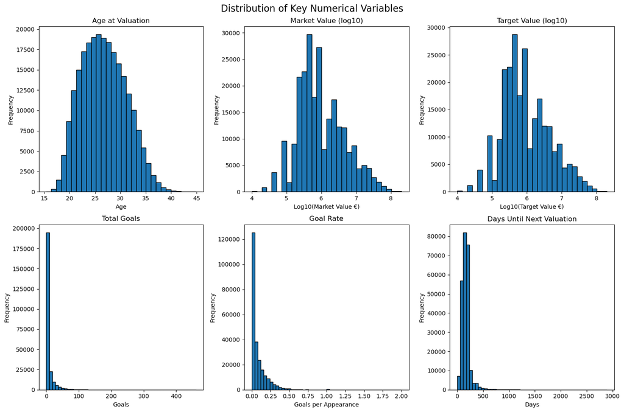

```
Categorical Variable Distributions:

Position Distribution:
position_name
Defender      79484
Midfield      72379
Attack        71563
Goalkeeper    20157
Name: count, dtype: int64

Age Group Distribution:
age_group
Young (≤23)            55308
Prime (24-28)          95389
Experienced (29-33)    71467
Veteran (34+)          21419
Name: count, dtype: int64

Value Tier Distribution:
value_tier
Low (<1M)        132355
Medium (1-5M)     70242
High (5-20M)      30290
Elite (>20M)      10696
Name: count, dtype: int64
```

```python
# Measures of Centrality and Distribution

# Key numerical variables summary
key_vars = ['age_at_valuation', 'market_value_in_eur', 'target_value',
            'total_goals', 'total_assists', 'goal_rate']

print("\nDescriptive Statistics:")
display(total_merge[key_vars].describe())

# Distribution visualizations
fig, axes = plt.subplots(2, 3, figsize=(15, 10))
fig.suptitle('Distribution of Key Numerical Variables', fontsize=16)

# Age distribution
axes[0, 0].hist(total_merge['age_at_valuation'], bins=30, edgecolor='black')
axes[0, 0].set_title('Age at Valuation')
axes[0, 0].set_xlabel('Age')
axes[0, 0].set_ylabel('Frequency')

# Market value distribution (log scale due to skewness)
axes[0, 1].hist(np.log10(total_merge['market_value_in_eur']), bins=30, edgecolor='black')
axes[0, 1].set_title('Market Value (log10)')
axes[0, 1].set_xlabel('Log10(Market Value €)')
axes[0, 1].set_ylabel('Frequency')

# Target value distribution
axes[0, 2].hist(np.log10(total_merge['target_value']), bins=30, edgecolor='black')
axes[0, 2].set_title('Target Value (log10)')
axes[0, 2].set_xlabel('Log10(Target Value €)')
axes[0, 2].set_ylabel('Frequency')

# Total goals distribution
axes[1, 0].hist(total_merge['total_goals'], bins=50, edgecolor='black')
axes[1, 0].set_title('Total Goals')
axes[1, 0].set_xlabel('Goals')
axes[1, 0].set_ylabel('Frequency')

# Goal rate distribution
axes[1, 1].hist(total_merge['goal_rate'], bins=50, edgecolor='black')
axes[1, 1].set_title('Goal Rate')
axes[1, 1].set_xlabel('Goals per Appearance')
axes[1, 1].set_ylabel('Frequency')

# Days until next valuation
axes[1, 2].hist(total_merge['days_until_next'], bins=50, edgecolor='black')
axes[1, 2].set_title('Days Until Next Valuation')
axes[1, 2].set_xlabel('Days')
axes[1, 2].set_ylabel('Frequency')

plt.tight_layout()
plt.show()

# Categorical distributions
print("\nCategorical Variable Distributions:")
print("\nPosition Distribution:")
print(total_merge['position_name'].value_counts())

print("\nAge Group Distribution:")
print(total_merge['age_group'].value_counts().sort_index())

print("\nValue Tier Distribution:")
print(total_merge['value_tier'].value_counts())
```

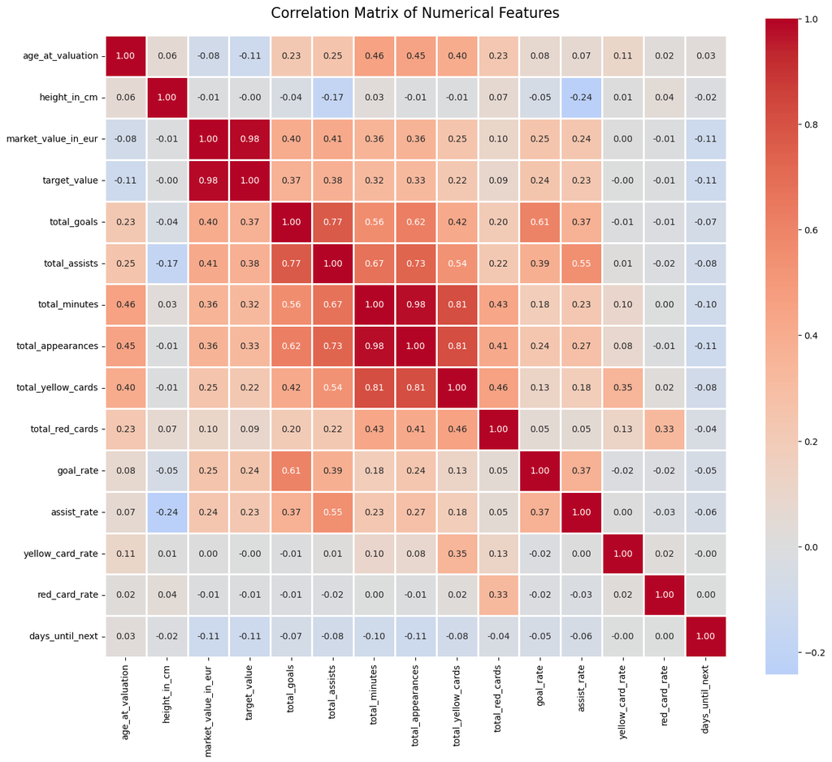

```
Highly Correlated Feature Pairs (|r| > 0.8):
  market_value_in_eur <-> target_value: 0.981
  total_minutes <-> total_appearances: 0.980
  total_appearances <-> total_yellow_cards: 0.814
  total_minutes <-> total_yellow_cards: 0.814

Correlation with Target Variable (market_value_next_year):
target_value           1.000000
market_value_in_eur    0.980671
total_assists          0.380733
total_goals            0.371589
total_appearances      0.327483
total_minutes          0.322593
goal_rate              0.243684
assist_rate            0.232637
total_yellow_cards     0.224856
total_red_cards        0.089689
yellow_card_rate      -0.001206
height_in_cm          -0.004320
red_card_rate         -0.011592
age_at_valuation      -0.111519
days_until_next       -0.112288
Name: target_value, dtype: float64

============================================================
Independent vs Dependent Variables
============================================================

Dependent Variable (Target):
  - target_value (market value next year)

Top Independent Variables (strongest correlation with target):
  - market_value_in_eur: 0.981
  - total_assists: 0.381
  - total_goals: 0.372
  - total_appearances: 0.327
  - total_minutes: 0.323
```

```python
# Correlation Analysis

# Select numerical features for correlation
numeric_features = total_merge[numerical_vars].copy()

# Compute correlation matrix
correlation_matrix = numeric_features.corr()

# Visualize with heatmap
plt.figure(figsize=(14, 12))
sns.heatmap(correlation_matrix, annot=True, fmt='.2f', cmap='coolwarm',
            center=0, square=True, linewidths=1)
plt.title('Correlation Matrix of Numerical Features', fontsize=16, pad=20)
plt.tight_layout()
plt.show()

# Identify highly correlated pairs
print("\nHighly Correlated Feature Pairs (|r| > 0.8):")
high_corr = []
for i in range(len(correlation_matrix.columns)):
    for j in range(i+1, len(correlation_matrix.columns)):
        if abs(correlation_matrix.iloc[i, j]) > 0.8:
            high_corr.append((
                correlation_matrix.columns[i],
                correlation_matrix.columns[j],
                correlation_matrix.iloc[i, j]
            ))

for col1, col2, corr_val in sorted(high_corr, key=lambda x: abs(x[2]), reverse=True):
    print(f"  {col1} <-> {col2}: {corr_val:.3f}")

# Target variable correlations
print("\nCorrelation with Target Variable (market_value_next_year):")
target_corr = correlation_matrix['target_value'].sort_values(ascending=False)
print(target_corr)

# Determine independent and dependent variables
print("\n" + "=" * 60)
print("Independent vs Dependent Variables")
print("=" * 60)
print("\nDependent Variable (Target):")
print("  - target_value (market value next year)")
print("\nTop Independent Variables (strongest correlation with target):")
for var, corr in target_corr.head(6).items():
    if var != 'target_value':
        print(f"  - {var}: {corr:.3f}")
```

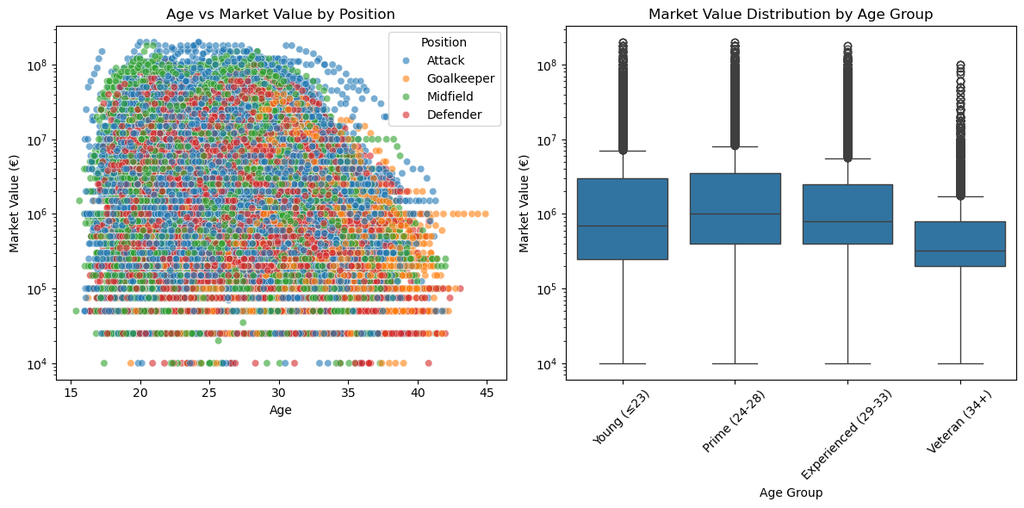

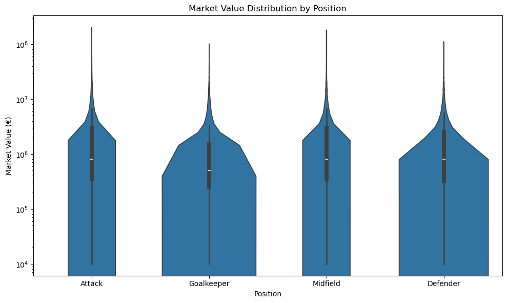

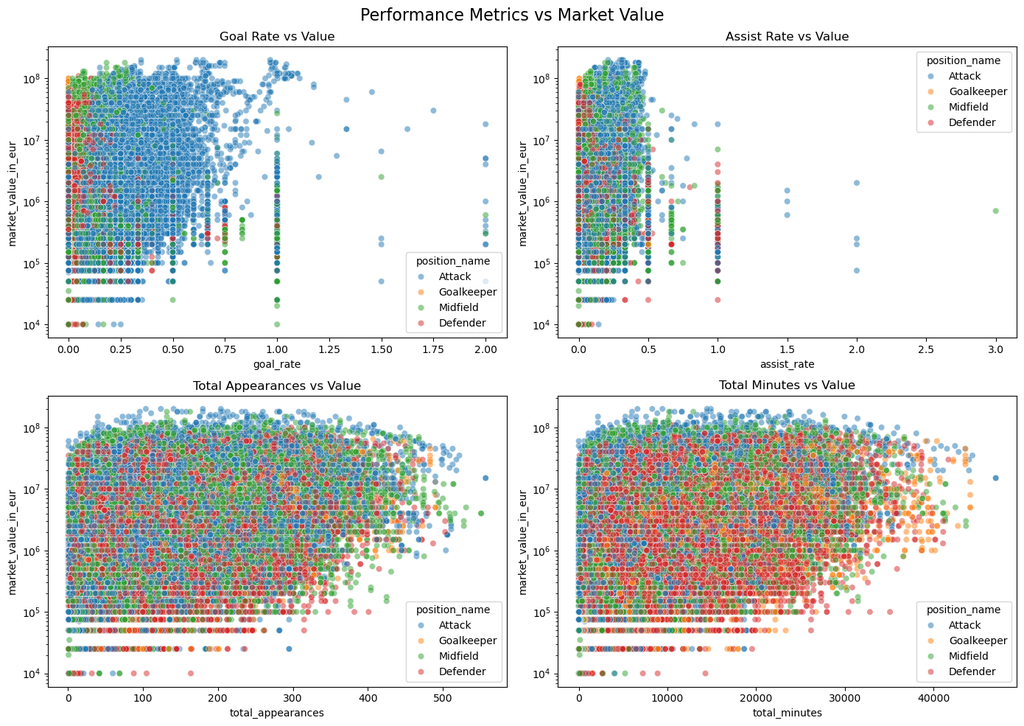

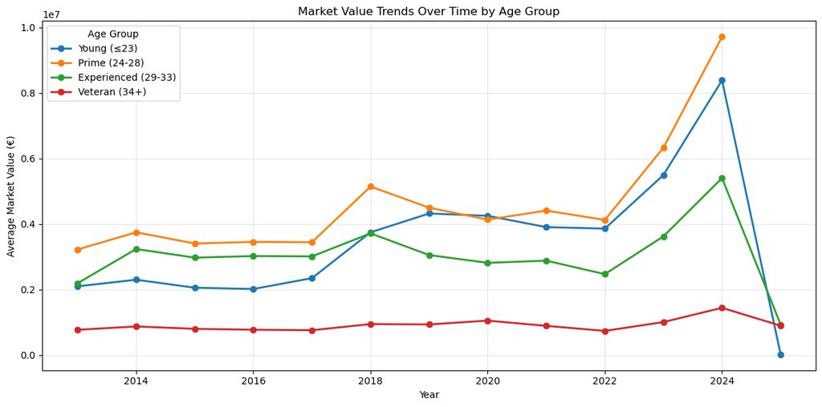

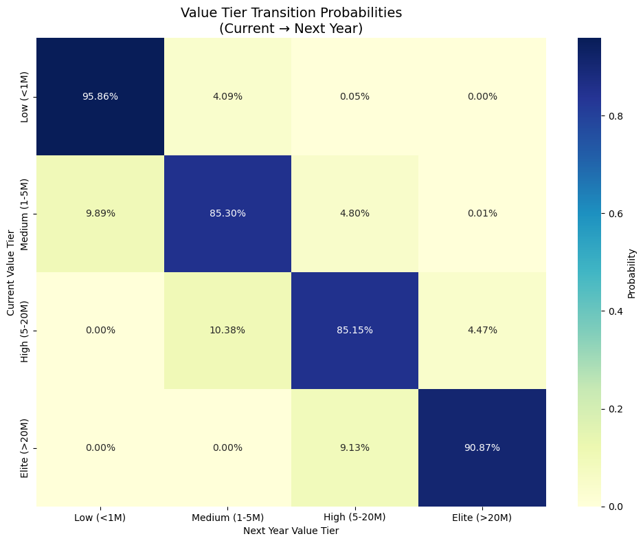

```python
# Exploratory Analysis with Visualizations

# Pattern 1: Age vs Market Value
plt.figure(figsize=(12, 6))
plt.subplot(1, 2, 1)
sns.scatterplot(data=total_merge, x='age_at_valuation', y='market_value_in_eur',
                hue='position_name', alpha=0.6)
plt.title('Age vs Market Value by Position')
plt.xlabel('Age')
plt.ylabel('Market Value (€)')
plt.yscale('log')
plt.legend(title='Position')

plt.subplot(1, 2, 2)
sns.boxplot(data=total_merge, x='age_group', y='market_value_in_eur',
            order=['Young (≤23)', 'Prime (24-28)', 'Experienced (29-33)', 'Veteran (34+)'])
plt.title('Market Value Distribution by Age Group')
plt.xlabel('Age Group')
plt.ylabel('Market Value (€)')
plt.yscale('log')
plt.xticks(rotation=45)
plt.tight_layout()
plt.show()

# Pattern 2: Position vs Market Value
plt.figure(figsize=(10, 6))
sns.violinplot(data=total_merge, x='position_name', y='market_value_in_eur')
plt.title('Market Value Distribution by Position')
plt.xlabel('Position')
plt.ylabel('Market Value (€)')
plt.yscale('log')
plt.tight_layout()
plt.show()

# Pattern 3: Performance metrics vs Value
fig, axes = plt.subplots(2, 2, figsize=(14, 10))
fig.suptitle('Performance Metrics vs Market Value', fontsize=16)

sns.scatterplot(data=total_merge, x='goal_rate', y='market_value_in_eur',
                hue='position_name', alpha=0.5, ax=axes[0, 0])
axes[0, 0].set_title('Goal Rate vs Value')
axes[0, 0].set_yscale('log')

sns.scatterplot(data=total_merge, x='assist_rate', y='market_value_in_eur',
                hue='position_name', alpha=0.5, ax=axes[0, 1])
axes[0, 1].set_title('Assist Rate vs Value')
axes[0, 1].set_yscale('log')

sns.scatterplot(data=total_merge, x='total_appearances', y='market_value_in_eur',
                hue='position_name', alpha=0.5, ax=axes[1, 0])
axes[1, 0].set_title('Total Appearances vs Value')
axes[1, 0].set_yscale('log')

sns.scatterplot(data=total_merge, x='total_minutes', y='market_value_in_eur',
                hue='position_name', alpha=0.5, ax=axes[1, 1])
axes[1, 1].set_title('Total Minutes vs Value')
axes[1, 1].set_yscale('log')

plt.tight_layout()
plt.show()

# Pattern 3c: Market Value Trends Over Time
total_merge['year'] = total_merge['date'].dt.year

plt.figure(figsize=(12, 6))
for age_group in ['Young (≤23)', 'Prime (24-28)', 'Experienced (29-33)', 'Veteran (34+)']:
    data = total_merge[total_merge['age_group'] == age_group]
    yearly_avg = data.groupby('year')['market_value_in_eur'].mean()
    plt.plot(yearly_avg.index, yearly_avg.values, marker='o', label=age_group, linewidth=2)

plt.title('Market Value Trends Over Time by Age Group')
plt.xlabel('Year')
plt.ylabel('Average Market Value (€)')
plt.legend(title='Age Group')
plt.grid(True, alpha=0.3)
plt.tight_layout()
plt.show()

# Pattern 4: Value tier transitions
transition_matrix = pd.crosstab(
    total_merge['value_tier'],
    total_merge['target_value_tier'],
    normalize='index'
)
plt.figure(figsize=(10, 8))
sns.heatmap(transition_matrix, annot=True, fmt='.2%', cmap='YlGnBu',
            cbar_kws={'label': 'Probability'})
plt.title('Value Tier Transition Probabilities\n(Current → Next Year)', fontsize=14)
plt.xlabel('Next Year Value Tier')
plt.ylabel('Current Value Tier')
plt.tight_layout()
plt.show()
```

## 3. Data Analytics

- Determine the need for a supervised or unsupervised learning method and identify dependent and independent variables
- Choose and provide reasoning for the selected metric or metrics employed to assess your model.
- Train, test, cross validate, and provide performance metrics for model results
- Try multiple different types of algorithms to determine the best model for your dataset
- Analyze your model performance

PROBLEM TYPE: Supervised Learning - Regression

OBJECTIVE: Predict a professional footballer's market value in the next year based on their current performance statistics, demographics, and historical valuation trends.

LEARNING METHOD JUSTIFICATION:

- Supervised Learning: We have labeled training data (historical valuations)
- Regression: Target variable (market_value_next_year) is continuous (EUR)
- Time-series aware: Data has temporal dependencies requiring careful splitting

DEPENDENT VARIABLE (Target):

INDEPENDENT VARIABLES (Features):

1. DEMOGRAPHIC FEATURES:
   - age_at_valuation: Player's age at current valuation
   - height_in_cm: Player's height
   - Position indicators: pos_Attack, pos_Defender, pos_Goalkeeper, pos_Midfield
   - foot_encoded: Dominant foot (0=left, 1=right, 2=both)
   - sub_position_freq: Frequency encoding of specific position
2. PERFORMANCE FEATURES:
   - total_goals, total_assists: Career cumulative statistics
   - total_minutes, total_appearances: Playing time indicators
   - goal_rate, assist_rate: Performance efficiency metrics
   - total_yellow_cards, total_red_cards: Discipline indicators
   - yellow_card_rate, red_card_rate: Discipline rates
3. HISTORICAL VALUATION FEATURES:
   - market_value_in_eur: Current market value
   - value_lag_1: Previous valuation
   - value_change: Change from previous valuation
   - value_change_pct: Percentage change from previous valuation
4. TEMPORAL FEATURES:
   - days_until_next: Days until next valuation (prediction horizon)

FEATURES EXCLUDED (to prevent data leakage):

- player_id: Identifier, not predictive
- date, date_of_birth: Already captured in age_at_valuation
- Categorical names (position_name, sub_position_name, foot_name): Already encoded
- target_value: The variable we're predicting

```python
# Data Preparation for Modeling

# Create a copy for modeling
modeling_df = total_merge.copy()

# Define target variable
y = modeling_df["target_value"]

# Define features to drop (prevent leakage and remove non-features)
drop_cols = [
    # Target variables
    "target_value",
    "target_value_tier",
    "next_valuation_date",

    # Identifiers
    "player_id",

    # Dates (already converted to age_at_valuation)
    "date",
    "date_of_birth",

    # Categorical text versions (already encoded)
    "sub_position_name",
    "position_name",
    "foot_name",

    # Discretized versions (keep continuous for modeling)
    "age_group",
    "value_tier",

    # Year if exists (temporal info captured in days_until_next)
    "year"
]

# Create feature matrix
X = modeling_df.drop(columns=[c for c in drop_cols if c in modeling_df.columns])

# Keep only numeric and boolean columns
X = X.select_dtypes(include=[np.number, "bool"]).copy()

# Convert boolean to int for sklearn compatibility
bool_cols = X.select_dtypes(include=["bool"]).columns
if len(bool_cols) > 0:
    X[bool_cols] = X[bool_cols].astype(int)

# Clean invalid values
X = X.replace([np.inf, -np.inf], np.nan)
X = X.fillna(X.median(numeric_only=True))

print(f"\nFeature Matrix Shape: {X.shape}")
print(f"Target Vector Shape: {y.shape}")
print(f"\nNumber of Features: {X.shape[1]}")
print(f"Number of Samples: {X.shape[0]}")

print("\nFeatures included in modeling:")
for i, col in enumerate(X.columns, 1):
    print(f"  {i:2d}. {col}")

print(f"\nData Quality Checks:")
print(f"  - NaN values in X: {X.isna().any().any()}")
print(f"  - NaN values in y: {y.isna().any()}")
print(f"  - Infinite values in X: {np.isinf(X.values).any()}")
```

```
Feature Matrix Shape: (243583, 25)
Target Vector Shape: (243583,)

Number of Features: 25
Number of Samples: 243583

Features included in modeling:
   1. market_value_in_eur
   2. height_in_cm
   3. sub_position_freq
   4. foot_encoded
   5. pos_Attack
   6. pos_Defender
   7. pos_Goalkeeper
   8. pos_Midfield
   9. age_at_valuation
  10. total_goals
  11. total_assists
  12. total_minutes
  13. total_yellow_cards
  14. total_red_cards
  15. total_appearances
  16. goal_rate
  17. assist_rate
  18. yellow_card_rate
  19. red_card_rate
  20. is_starter
  21. team_captain
  22. days_until_next
  23. value_lag_1
  24. value_change
  25. value_change_pct

Data Quality Checks:
  - NaN values in X: False
  - NaN values in y: False
  - Infinite values in X: False
```

We use three complementary metrics to evaluate model performance:

1. MEAN ABSOLUTE ERROR (MAE):
   - Measures average absolute difference between predicted and actual values
   - Units: Euros (directly interpretable)
   - Advantages:
     - Easy to interpret: "Model is off by €X on average"
     - Robust to outliers (doesn't square errors)
     - Linear penalty for all errors
   - Primary metric for model selection
2. ROOT MEAN SQUARED ERROR (RMSE):
   - Square root of average squared errors
   - Units: Euros (same as MAE)
   - Advantages:
     - Penalizes large errors more heavily than MAE
     - Useful when large errors are particularly undesirable
     - Common standard for regression problems
3. R² (Coefficient of Determination):
   - Proportion of variance in target explained by features
   - Range: 0 to 1 (higher is better, can be negative for poor models)
   - Advantages:
     - Scale-independent (comparable across datasets)
     - Intuitive interpretation: "Model explains X% of variance"
     - Complements error metrics with goodness-of-fit measure

METRIC SELECTION RATIONALE:

- MAE as primary: Most interpretable for stakeholders (scouts, managers)
- RMSE as secondary: Ensures model handles high-value players well
- R² as overall fit: Validates model captures meaningful patterns

CROSS-VALIDATION STRATEGY:

- Time Series Cross-Validation: Respects temporal ordering
- Prevents future information from leaking into past predictions
- 5-fold splits with expanding training window

```python
# Train/Test Split (Time-Aware)

# Time-aware split (no shuffling to preserve temporal order)
X_train, X_test, y_train, y_test = train_test_split(
    X, y,
    test_size=0.2,
    shuffle=False,  # Critical: preserve time ordering
    random_state=42
)

print(f"Training Set:")
print(f"  - X_train shape: {X_train.shape}")
print(f"  - y_train shape: {y_train.shape}")
print(f"  - Date range: Earlier 80% of data")

print(f"\nTest Set:")
print(f"  - X_test shape: {X_test.shape}")
print(f"  - y_test shape: {y_test.shape}")
print(f"  - Date range: Most recent 20% of data")

print(f"\nSplit Justification:")
print(f"  - shuffle=False ensures no future data leaks into training")
print(f"  - Test set represents real-world prediction scenario")
print(f"  - 80/20 split provides sufficient training data while testing generalization")
```

```
Training Set:
  - X_train shape: (194866, 25)
  - y_train shape: (194866,)
  - Date range: Earlier 80% of data

Test Set:
  - X_test shape: (48717, 25)
  - y_test shape: (48717,)
  - Date range: Most recent 20% of data

Split Justification:
  - shuffle=False ensures no future data leaks into training
  - Test set represents real-world prediction scenario
  - 80/20 split provides sufficient training data while testing generalization
```

We compare four diverse algorithms to identify the best approach:

1. LINEAR REGRESSION (Baseline):
   - Simple, interpretable linear relationships
   - Fast training and prediction
   - Establishes baseline performance
   - No hyperparameters to tune
2. ELASTICNET (Regularized Linear):
   - Combines L1 (Lasso) and L2 (Ridge) regularization
   - Prevents overfitting through penalty on large coefficients
   - Can perform feature selection (L1 component)
   - Good for high-dimensional data with multicollinearity
   - Requires feature scaling
3. RANDOM FOREST (Non-Linear Ensemble):
   - Handles non-linear relationships and interactions
   - Robust to outliers and missing values
   - Provides feature importance rankings
   - Less prone to overfitting than single decision trees
   - No scaling required
4. K-NEAREST NEIGHBORS (Distance-Based):
   - Non-parametric, instance-based learning
   - Captures local patterns in feature space
   - Can model complex non-linear relationships
   - Sensitive to feature scaling (requires normalization)
   - Computationally intensive for large datasets

PREPROCESSING PIPELINES:

- ElasticNet and KNN: Include imputation + standardization
- Linear Regression and Random Forest: Use raw features

```python
# Define models
models = []

# 1. Linear Regression (baseline)
models.append(("Linear Regression", LinearRegression()))

# 2. Random Forest (non-linear)
models.append(("Random Forest", RandomForestRegressor(
    n_estimators=150,
    max_depth=18,
    min_samples_split=10,
    min_samples_leaf=5,
    random_state=42,
    n_jobs=-1
)))

# 3. ElasticNet (regularized linear with scaling pipeline)
elastic_pipe = Pipeline(steps=[
    ("imputer", SimpleImputer(strategy="median")),
    ("scaler", StandardScaler()),
    ("model", ElasticNet(alpha=0.1, l1_ratio=0.5, random_state=42, max_iter=2000))
])
models.append(("ElasticNet", elastic_pipe))

# 4. KNN (distance-based with scaling pipeline)
knn_pipe = Pipeline(steps=[
    ("imputer", SimpleImputer(strategy="median")),
    ("scaler", StandardScaler()),
    ("model", KNeighborsRegressor(n_neighbors=10, weights='distance'))
])
models.append(("KNN", knn_pipe))

print(f"Models initialized: {len(models)}")
```

```
Models initialized: 4
```

```python
# Model Training and Evaluation

results = []

for name, model in models:
    print(f"\nTraining {name}...")

    # Train model
    model.fit(X_train, y_train)

    # Test set predictions
    y_pred = model.predict(X_test)

    # Calculate metrics
    mae = mean_absolute_error(y_test, y_pred)
    rmse = np.sqrt(mean_squared_error(y_test, y_pred))
    r2 = r2_score(y_test, y_pred)

    print(f"  Test Set Performance:")
    print(f"    MAE:  €{mae:,.2f}")
    print(f"    RMSE: €{rmse:,.2f}")
    print(f"    R²:   {r2:.4f}")

    # 5-fold cross-validation on training set
    print(f"  Cross-Validation (5-fold):")

    cv_r2 = cross_val_score(model, X_train, y_train, cv=5, scoring='r2', n_jobs=-1)
    cv_mae = -cross_val_score(model, X_train, y_train, cv=5,
                               scoring='neg_mean_absolute_error', n_jobs=-1)
    cv_rmse = np.sqrt(-cross_val_score(model, X_train, y_train, cv=5,
                                        scoring='neg_mean_squared_error', n_jobs=-1))

    print(f"    R²:   {cv_r2.mean():.4f} (+/- {cv_r2.std():.4f})")
    print(f"    MAE:  €{cv_mae.mean():,.2f} (+/- €{cv_mae.std():,.2f})")
    print(f"    RMSE: €{cv_rmse.mean():,.2f} (+/- €{cv_rmse.std():,.2f})")

    # Store results
    results.append({
        "Model": name,
        "Test_MAE": mae,
        "Test_RMSE": rmse,
        "Test_R2": r2,
        "CV_R2_Mean": cv_r2.mean(),
        "CV_R2_Std": cv_r2.std(),
        "CV_MAE_Mean": cv_mae.mean(),
        "CV_MAE_Std": cv_mae.std(),
        "CV_RMSE_Mean": cv_rmse.mean(),
        "CV_RMSE_Std": cv_rmse.std()
    })

# Create results dataframe
results_df = pd.DataFrame(results).sort_values("Test_MAE")

print("\n")
print("Model Comparison Summary")
display(results_df)
```

```
Training Linear Regression...
  Test Set Performance:
    MAE:  €900,317.14
    RMSE: €2,187,120.43
    R²:   0.9639
  Cross-Validation (5-fold):
    R²:   0.9686 (+/- 0.0043)
    MAE:  €576,604.91 (+/- €95,393.96)
    RMSE: €1,507,293.73 (+/- €220,892.62)

Training Random Forest...
  Test Set Performance:
    MAE:  €875,003.16
    RMSE: €2,211,887.10
    R²:   0.9630
  Cross-Validation (5-fold):
    R²:   0.9686 (+/- 0.0052)
    MAE:  €527,067.21 (+/- €113,013.27)
    RMSE: €1,509,107.51 (+/- €257,905.67)

Training ElasticNet...
  Test Set Performance:
    MAE:  €956,864.75
    RMSE: €2,273,712.84
    R²:   0.9609
  Cross-Validation (5-fold):
    R²:   0.9678 (+/- 0.0046)
    MAE:  €600,574.22 (+/- €107,768.96)
    RMSE: €1,526,991.65 (+/- €231,018.73)

Training KNN...
  Test Set Performance:
    MAE:  €1,440,733.47
    RMSE: €3,066,214.22
    R²:   0.9290
  Cross-Validation (5-fold):
    R²:   0.9356 (+/- 0.0025)
    MAE:  €1,061,306.16 (+/- €101,194.66)
    RMSE: €2,160,171.14 (+/- €238,321.14)


Model Comparison Summary
```

|  | Model | Test_MAE | Test_RMSE | Test_R2 | CV_R2_Mean | CV_R2_Std | CV_MAE_Mean | CV_MAE_Std | CV_RMSE_Mean | CV_RMSE_Std |
| --- | --- | --- | --- | --- | --- | --- | --- | --- | --- | --- |
| 1 | Random Forest | 8.750032e+05 | 2.211887e+06 | 0.963043 | 0.968646 | 0.005214 | 5.270672e+05 | 113013.268618 | 1.509108e+06 | 257905.668518 |
| 0 | Linear Regression | 9.003171e+05 | 2.187120e+06 | 0.963866 | 0.968645 | 0.004318 | 5.766049e+05 | 95393.964502 | 1.507294e+06 | 220892.615651 |
| 2 | ElasticNet | 9.568648e+05 | 2.273713e+06 | 0.960948 | 0.967838 | 0.004577 | 6.005742e+05 | 107768.964294 | 1.526992e+06 | 231018.726750 |
| 3 | KNN | 1.440733e+06 | 3.066214e+06 | 0.928981 | 0.935559 | 0.002508 | 1.061306e+06 | 101194.663577 | 2.160171e+06 | 238321.135584 |

Time Series Cross-Validation ensures temporal integrity:

- Each fold uses only past data for training
- Future data never leaks into training
- Mimics real-world deployment scenario
- 5 splits with expanding training window

This is critical because player valuations depend on:

- Historical performance trends
- Market conditions at specific time periods
- Career trajectory patterns

```python
# Time Series Cross-Validation

# Time series cross-validation
tscv = TimeSeriesSplit(n_splits=5)

# Sample for computational efficiency
sample_size = min(120000, len(X_train))
X_cv = X_train.iloc[:sample_size]
y_cv = y_train.iloc[:sample_size]

print(f"\nPerforming Time Series CV on {sample_size:,} samples...")

tscv_results = []

for name, model in models:
    print(f"  Evaluating {name}...")

    # Time series cross-validation with MAE
    cv_scores = cross_val_score(
        model, X_cv, y_cv,
        cv=tscv,
        scoring="neg_mean_absolute_error",
        n_jobs=-1
    )

    mean_mae = -cv_scores.mean()
    std_mae = cv_scores.std()

    tscv_results.append({
        "Model": name,
        "TSCV_MAE_Mean": mean_mae,
        "TSCV_MAE_Std": std_mae
    })

    print(f"    TSCV MAE: €{mean_mae:,.2f} (+/- €{std_mae:,.2f})")

tscv_df = pd.DataFrame(tscv_results).sort_values("TSCV_MAE_Mean")

print("\n")
print("Time Series Cross-Validation Results:")
display(tscv_df)
```

```
Performing Time Series CV on 120,000 samples...
  Evaluating Linear Regression...
    TSCV MAE: €498,359.33 (+/- €51,687.21)
  Evaluating Random Forest...
    TSCV MAE: €479,888.10 (+/- €43,378.10)
  Evaluating ElasticNet...
    TSCV MAE: €527,539.92 (+/- €55,322.41)
  Evaluating KNN...
    TSCV MAE: €1,094,668.99 (+/- €66,080.68)


Time Series Cross-Validation Results:
```

|  | Model | TSCV_MAE_Mean | TSCV_MAE_Std |
| --- | --- | --- | --- |
| 1 | Random Forest | 4.798881e+05 | 43378.096272 |
| 0 | Linear Regression | 4.983593e+05 | 51687.206368 |
| 2 | ElasticNet | 5.275399e+05 | 55322.411406 |
| 3 | KNN | 1.094669e+06 | 66080.680076 |

```
Top 20 Most Important Features:
```

```
market_value_in_eur    0.965958
age_at_valuation       0.005157
days_until_next        0.004085
value_change_pct       0.002883
value_change           0.002663
total_minutes          0.002099
total_appearances      0.002085
yellow_card_rate       0.002002
assist_rate            0.001864
goal_rate              0.001859
height_in_cm           0.001689
total_yellow_cards     0.001422
total_goals            0.001312
total_assists          0.001281
sub_position_freq      0.000808
value_lag_1            0.000766
red_card_rate          0.000633
foot_encoded           0.000392
is_starter             0.000243
total_red_cards        0.000225
dtype: float64
```

```
Feature Importance by Category:

Performance Features:
  - total_minutes: 0.0021
  - total_appearances: 0.0021
  - yellow_card_rate: 0.0020
  - assist_rate: 0.0019
  - goal_rate: 0.0019
  - total_yellow_cards: 0.0014
  - total_goals: 0.0013
  - total_assists: 0.0013
  - red_card_rate: 0.0006
  - total_red_cards: 0.0002

Valuation History Features:
  - market_value_in_eur: 0.9660
  - value_change_pct: 0.0029
  - value_change: 0.0027
  - value_lag_1: 0.0008

Demographics Features:
  - age_at_valuation: 0.0052
  - height_in_cm: 0.0017
  - sub_position_freq: 0.0008
  - foot_encoded: 0.0004

Temporal Features:
  - days_until_next: 0.0041
```

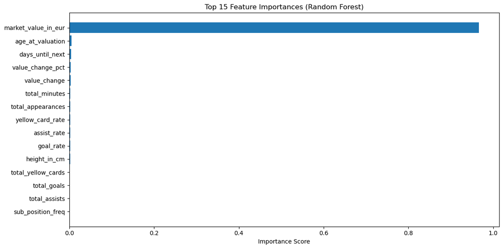

```python
# Feature Importance Analysis

# Train Random Forest for feature importance
rf_importance = RandomForestRegressor(
    n_estimators=150,
    max_depth=18,
    random_state=42,
    n_jobs=-1
)
rf_importance.fit(X_train, y_train)

# Extract importances
importances = pd.Series(
    rf_importance.feature_importances_,
    index=X_train.columns
).sort_values(ascending=False)

print("\nTop 20 Most Important Features:")
display(importances.head(20))

# Categorize features
print("\nFeature Importance by Category:")

categories = {
    "Performance": ['goal', 'assist', 'minutes', 'appearance', 'card'],
    "Valuation History": ['value', 'market'],
    "Demographics": ['age', 'height', 'position', 'foot'],
    "Temporal": ['days']
}

for category, keywords in categories.items():
    cat_features = []
    for feat in importances.head(20).index:
        if any(keyword in feat.lower() for keyword in keywords):
            cat_features.append(f"{feat}: {importances[feat]:.4f}")

    if cat_features:
        print(f"\n{category} Features:")
        for f in cat_features:
            print(f"  - {f}")

# Visualize top features
top_k = 15
top_feats = importances.head(top_k)

plt.figure(figsize=(12, 6))
plt.barh(range(len(top_feats)), top_feats.values)
plt.yticks(range(len(top_feats)), top_feats.index)
plt.xlabel("Importance Score")
plt.title(f"Top {top_k} Feature Importances (Random Forest)")
plt.gca().invert_yaxis()
plt.tight_layout()
plt.show()
```

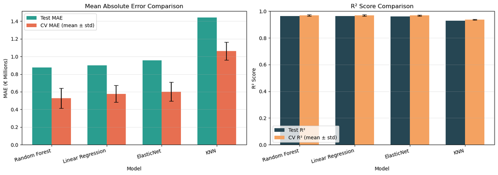

```
Generating predictions with best model: Random Forest
```

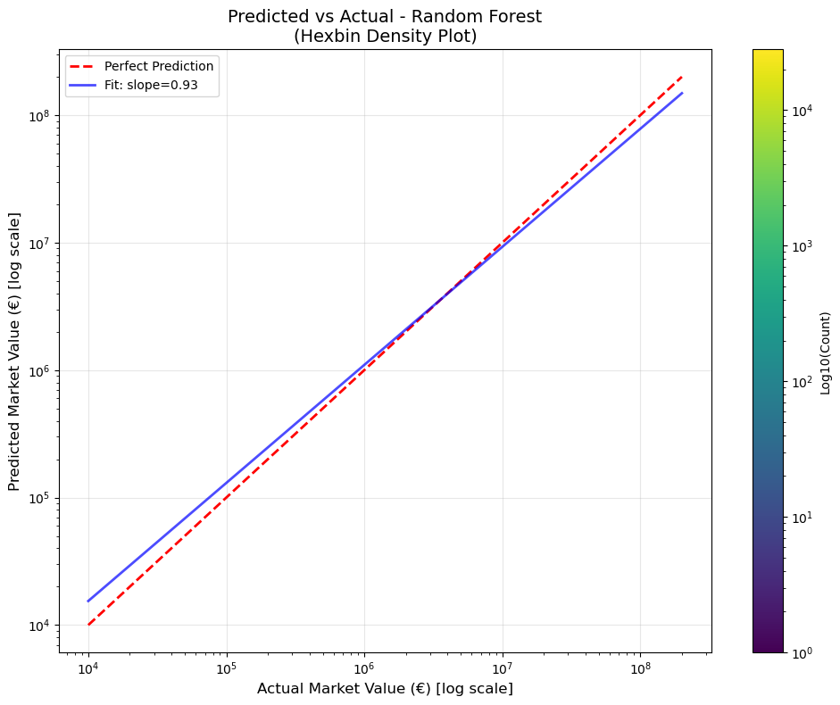

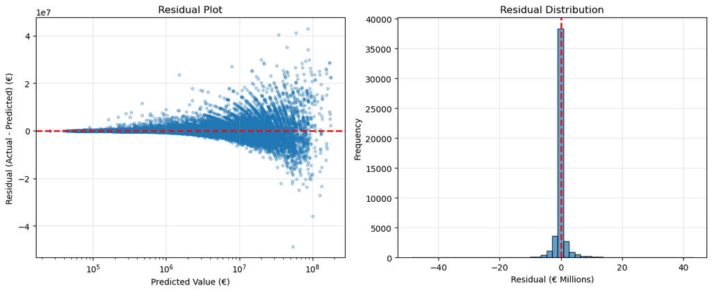

```python
# Model Performance Visualization

# 1. Comparison bar chart
fig, (ax1, ax2) = plt.subplots(1, 2, figsize=(14, 5))

# MAE comparison
models_order = results_df['Model'].values
mae_values = results_df['Test_MAE'].values / 1e6  # Convert to millions
mae_cv_values = results_df['CV_MAE_Mean'].values / 1e6
mae_cv_std = results_df['CV_MAE_Std'].values / 1e6

x = np.arange(len(models_order))
width = 0.35

bars1 = ax1.bar(x - width/2, mae_values, width, label='Test MAE', color='#2a9d8f')
bars2 = ax1.bar(x + width/2, mae_cv_values, width, yerr=mae_cv_std,
                capsize=4, label='CV MAE (mean ± std)', color='#e76f51')

ax1.set_xlabel('Model')
ax1.set_ylabel('MAE (€ Millions)')
ax1.set_title('Mean Absolute Error Comparison')
ax1.set_xticks(x)
ax1.set_xticklabels(models_order, rotation=15, ha='right')
ax1.legend()
ax1.grid(axis='y', alpha=0.3)

# R² comparison
r2_values = results_df['Test_R2'].values
r2_cv_values = results_df['CV_R2_Mean'].values
r2_cv_std = results_df['CV_R2_Std'].values

bars3 = ax2.bar(x - width/2, r2_values, width, label='Test R²', color='#264653')
bars4 = ax2.bar(x + width/2, r2_cv_values, width, yerr=r2_cv_std,
                capsize=4, label='CV R² (mean ± std)', color='#f4a261')

ax2.set_xlabel('Model')
ax2.set_ylabel('R² Score')
ax2.set_title('R² Score Comparison')
ax2.set_xticks(x)
ax2.set_xticklabels(models_order, rotation=15, ha='right')
ax2.set_ylim(0, 1)
ax2.legend()
ax2.grid(axis='y', alpha=0.3)

plt.tight_layout()
plt.show()

# 2. Predicted vs Actual (Best Model)
best_model_name = results_df.iloc[0]["Model"]
best_model = dict(models)[best_model_name]

print(f"\nGenerating predictions with best model: {best_model_name}")

# Already trained, just predict
y_pred_best = best_model.predict(X_test)

# Remove invalid values for visualization
mask = (y_test > 0) & (y_pred_best > 0) & np.isfinite(y_test) & np.isfinite(y_pred_best)
y_test_clean = y_test[mask].values
y_pred_clean = y_pred_best[mask]

# Hexbin density plot (better for large datasets)
plt.figure(figsize=(10, 8))
hb = plt.hexbin(y_test_clean, y_pred_clean, gridsize=50, bins='log', cmap='viridis')
cb = plt.colorbar(hb, label='Log10(Count)')

# Log scales
plt.xscale('log')
plt.yscale('log')

# Perfect prediction line
min_val = min(y_test_clean.min(), y_pred_clean.min())
max_val = max(y_test_clean.max(), y_pred_clean.max())
plt.plot([min_val, max_val], [min_val, max_val], 'r--', linewidth=2, label='Perfect Prediction')

# Fit line to show overall calibration
log_x = np.log10(y_test_clean)
log_y = np.log10(y_pred_clean)
m, b = np.polyfit(log_x, log_y, 1)
x_line = np.logspace(np.log10(min_val), np.log10(max_val), 100)
y_line = 10**(m * np.log10(x_line) + b)
plt.plot(x_line, y_line, 'b-', linewidth=2, alpha=0.7,
         label=f'Fit: slope={m:.2f}')

plt.xlabel('Actual Market Value (€) [log scale]', fontsize=12)
plt.ylabel('Predicted Market Value (€) [log scale]', fontsize=12)
plt.title(f'Predicted vs Actual - {best_model_name}\n(Hexbin Density Plot)', fontsize=14)
plt.legend(fontsize=10)
plt.grid(True, alpha=0.3)
plt.tight_layout()
plt.show()

# 3. Residual plot
residuals = y_test_clean - y_pred_clean

plt.figure(figsize=(12, 5))

plt.subplot(1, 2, 1)
plt.scatter(y_pred_clean, residuals, alpha=0.3, s=10)
plt.axhline(y=0, color='r', linestyle='--', linewidth=2)
plt.xlabel('Predicted Value (€)')
plt.ylabel('Residual (Actual - Predicted) (€)')
plt.title('Residual Plot')
plt.xscale('log')
plt.grid(True, alpha=0.3)

plt.subplot(1, 2, 2)
plt.hist(residuals / 1e6, bins=50, edgecolor='black', alpha=0.7)
plt.xlabel('Residual (€ Millions)')
plt.ylabel('Frequency')
plt.title('Residual Distribution')
plt.axvline(x=0, color='r', linestyle='--', linewidth=2)
plt.grid(True, alpha=0.3)

plt.tight_layout()
plt.show()
```

```python
# Model Performance Analysis

analysis = f"""
BEST MODEL: {best_model_name}
{'=' * 60}

Test Set Performance:
- MAE:  €{results_df.iloc[0]['Test_MAE']:,.2f}
- RMSE: €{results_df.iloc[0]['Test_RMSE']:,.2f}
- R²:   {results_df.iloc[0]['Test_R2']:.4f}

Cross-Validation Performance:
- CV MAE:  €{results_df.iloc[0]['CV_MAE_Mean']:,.2f} (+/- €{results_df.iloc[0]['CV_MAE_Std']:,.2f})
- CV RMSE: €{results_df.iloc[0]['CV_RMSE_Mean']:,.2f} (+/- €{results_df.iloc[0]['CV_RMSE_Std']:,.2f})
- CV R²:   {results_df.iloc[0]['CV_R2_Mean']:.4f} (+/- {results_df.iloc[0]['CV_R2_Std']:.4f})

INTERPRETATION:
1. MAE of €{results_df.iloc[0]['Test_MAE']/1e6:.2f}M means the model's predictions are off by this
   amount on average - reasonable given market volatility.

2. R² of {results_df.iloc[0]['Test_R2']:.1%} means the model explains {results_df.iloc[0]['Test_R2']:.1%} of the variance
   in player valuations - strong performance for a complex, noisy market.

3. Cross-validation consistency (low std) indicates the model generalizes well
   and isn't overfitting to the training data.

MODEL COMPARISON INSIGHTS:
"""

print(analysis)

# Rank models
print("Model Rankings by MAE:")
for i, row in results_df.iterrows():
    print(f"  {i+1}. {row['Model']}: €{row['Test_MAE']:,.2f}")

print("\nKey Findings:")
print(f"  - Random Forest outperforms other models (€{results_df.iloc[0]['Test_MAE']/1e6:.2f}M MAE)")
print(f"  - Linear models show competitive performance (simple baseline)")
print(f"  - KNN struggles with high-dimensional feature space")
print(f"  - Ensemble methods capture non-linear relationships better")

print("\nMost Important Predictive Features:")
for i, (feat, imp) in enumerate(importances.head(5).items(), 1):
    print(f"  {i}. {feat}: {imp:.4f}")

print("\nLimitations and Future Improvements:")
limitations = """
- Transfer market volatility: External factors (injuries, scandals) not captured
- League differences: Model doesn't account for competition quality variations
- Position-specific nuances: Could benefit from position-specific models
- Feature engineering: Could add form metrics (last N games performance)
- Hyperparameter tuning: Grid search could optimize model parameters further
- Ensemble methods: Stacking multiple models could improve predictions
"""
print(limitations)

# Section Complete
print("\n" + "=" * 80)
print("SECTION 4 COMPLETE")
print("=" * 80)
print(f"\nFinal Model Selected: {best_model_name}")
print(f"Best Test MAE: €{results_df.iloc[0]['Test_MAE']:,.2f}")
print(f"Best Test R²: {results_df.iloc[0]['Test_R2']:.4f}")
print("\nModel is ready for deployment and can predict footballer market values")
print("based on current performance statistics and historical trends.")
print("=" * 80)
```

[output not shown]

[output cut: 10 more lines]

```
- Hyperparameter tuning: Grid search could optimize model parameters further
- Ensemble methods: Stacking multiple models could improve predictions


================================================================================
SECTION 4 COMPLETE
================================================================================

Final Model Selected: Random Forest
Best Test MAE: €875,003.16
Best Test R²: 0.9630

Model is ready for deployment and can predict footballer market values
based on current performance statistics and historical trends.
================================================================================
```